# Projekt z SZEREGÓW CZASOWYCH

Martyna Pitera

2023-06-13

# Wprowadzenie

Celem projektu jest analiza dwóch szeregów czasowych.

Analizowane szeregi czasowe dotyczą wielkości populacji ludzi w wieku powyżej 55 roku życia (włącznie) oraz cen warzyw w Polsce. Oba zbiory danych pochodzą ze strony https://fred.stlouisfed.org/.  
(fred.stlouisfed.org - baza danych Rezerwy Federalnej)

Analiza pierwszego zagadnienia ma na celu obserwację zmian zachodzących w społeczeństwie na całym świecie. Przewidywanie takich procesów jak starzenie się (lub odmładzanie) społeczeństwa wpływa np. na decyzje polityczne w sprawach polityki prorodzinnej czy prodemograficznej. Dane dotyczące populacji pochodzą z okresu od stycznia 1948 do maja 2023.

Analiza cen warzyw w Polsce pozwoli zobrazować, jak na przestrzeni roku zmieniają się ceny warzyw. W zależności od miesiąca, wahania cen są mocno zauważalne; w trakcie zbiorów są najtańsze, a pożniej drożeją, co można powiązać np. z kosztami magazynowania i przechowywania w odpowiednich warunkach.

# Wczytanie danych

```r
setwd('C:/Users/marty/Desktop/GITHUB/ts')
pop <- read.csv('pop.csv')
veg <- read.csv('veg.csv')

colnames(pop) <- c('data','liczba')
colnames(veg) <- c('data', 'cena')

pop$data <- as.Date(pop$data)
pop$liczba <- as.numeric(pop$liczba)

veg$data <- as.Date(veg$data)
veg$cena <- as.numeric(veg$cena)

pop <- ts(pop$liczba, start=1948, frequency = 12)
pop
```

```
##        Jan   Feb   Mar   Apr   May   Jun   Jul   Aug   Sep   Oct   Nov   Dec
## 1948 23311 23356 23407 23437 23492 23543 23650 23703 23761 23821 23876 23927
## 1949 23972 24016 24072 24117 24171 24220 24240 24297 24350 24418 24465 24527
## 1950 24568 24615 24668 24719 24756 24804 24860 24891 24947 25012 25060 25111
## 1951 25154 25195 25248 25281 25329 25375 25430 25486 25544 25600 25654 25708
## 1952 25746 25790 25840 25876 25926 25978 26034 26088 26146 26206 26260 26311
## 1953 26643 26691 26730 26760 26812 26866 26916 26972 27033 27093 27142 27197
## 1954 27247 27291 27336 27356 27401 27421 27441 27497 27549 27610 27671 27722
## 1955 27767 27807 27860 27899 27955 28008 28063 28115 28169 28224 28274 28329
## 1956 28366 28405 28458 28483 28554 28594 28583 28623 28682 28739 28790 28834
## 1957 28870 28913 28954 28998 29034 29093 29109 29160 29208 29263 29307 29341
## 1958 29366 29395 29438 29461 29499 29540 29579 29629 29688 29747 29796 29844
## 1959 29884 29920 29958 29997 30043 30083 30131 30185 30239 30288 30337 30389
## 1960 30509 30546 30596 30612 30648 30697 30750 30801 30858 30916 30983 31042
## 1961 31088 31124 31161 31220 31278 31324 31382 31441 31494 31555 31609 31658
```

[output cut: 62 more lines]

```r
veg <- ts(veg$cena, start=1996, frequency = 12)
veg
```

```
##        Jan   Feb   Mar   Apr   May   Jun   Jul   Aug   Sep   Oct   Nov   Dec
## 1996  55.3  60.3  68.5  80.2  95.9  91.2  74.4  62.5  67.2  70.2  63.0  58.4
## 1997  63.0  63.2  64.3  69.5  70.2  80.1  62.4  48.1  54.1  58.0  64.8  71.1
## 1998  76.4  79.5  82.5  87.4  87.0  86.6  64.1  43.7  52.3  58.3  63.6  69.8
## 1999  71.5  71.5  73.9  78.2  82.1  85.7  63.2  51.4  61.4  70.9  77.3  82.8
## 2000  86.0  89.0  91.9  95.8  91.0  84.6  67.6  54.3  61.1  65.3  68.2  74.1
## 2001  74.9  75.0  78.0  84.7  86.5  86.9  65.5  55.3  63.5  69.9  74.4  79.7
## 2002  89.5  92.3  96.9 100.4  92.0  86.8  61.9  52.6  60.6  69.9  72.6  76.6
## 2003  79.3  81.2  85.6  91.6  86.3  84.7  65.6  54.1  63.3  68.1  73.5  78.2
## 2004  80.9  81.3  82.9  85.8  81.0  86.9  67.0  58.1  62.5  65.5  70.5  75.6
## 2005  76.3  77.3  80.7  83.0  88.0  87.0  70.2  61.9  66.1  74.6  77.6  81.4
## 2006  85.4  89.5  91.4  96.1 100.1  95.4  76.0  76.4  80.0  86.7  89.2  90.2
## 2007  95.0  98.4 101.4 108.7 112.8 104.4  78.5  67.6  72.9  75.4  82.9  87.9
## 2008  88.9  89.2  90.6  94.0  98.4  95.7  82.6  69.9  74.4  80.5  87.3  93.4
## 2009  97.8 101.2 104.4 111.5 110.8 102.5  84.0  75.8  77.7  82.0  88.2  93.2
## 2010  99.9 104.7 108.8 115.7 116.2 113.7 102.2  86.1  96.2 103.4 107.8 111.8
## 2011 117.4 118.4 120.3 123.9 130.2 110.4  90.7  77.8  76.5  79.5  87.0  91.4
## 2012  96.9  99.9 103.7 100.6 107.6 108.9  88.5  80.8  79.2  83.1  88.3  98.1
## 2013 105.4 105.4 108.0 110.5 115.2 109.1 104.8  93.8  92.9  96.7 101.1 110.2
## 2014 117.7 116.9 114.9 113.0 105.5 104.6  94.7  82.6  85.8  88.1  92.4  95.8
## 2015 100.9 103.2 102.4 104.7 102.0 104.4  94.5  88.9  94.9 100.2 100.8 103.0
## 2016 107.6 109.3 111.0 114.3 113.0 113.2  99.3  91.1  88.8  91.9  94.5 103.2
## 2017 110.4 117.6 111.3 111.8 109.1 108.9  99.5  91.0  92.9  99.0 102.0 108.7
## 2018 113.7 111.8 111.0 114.0 112.9 109.2 103.2  98.4 102.4 109.1 111.9 120.1
## 2019 123.8 130.2 130.3 133.0 138.7 138.6 137.1 133.2 127.2 127.1 129.6 134.3
## 2020 138.2 141.1 140.4 143.6 140.9 137.5 123.6 117.2 117.1 119.7 124.6 125.6
## 2021 132.5 134.3 136.4 139.7 138.9 137.9 132.7 126.7 129.0 129.8 134.5 140.9
## 2022 147.2 147.6 150.4 157.2 151.9 149.4 141.2 138.6 140.5 152.1 155.3 160.9
## 2023 168.1 180.8 194.1 190.6
```

```r
is.ts(pop)
```

```
## [1] TRUE
```

```r
is.ts(veg)
```

```
## [1] TRUE
```

# Omówienie głównych cech analizowanych szeregów na podstawie poznanych typów wykresów

## a. wykresy punktowe

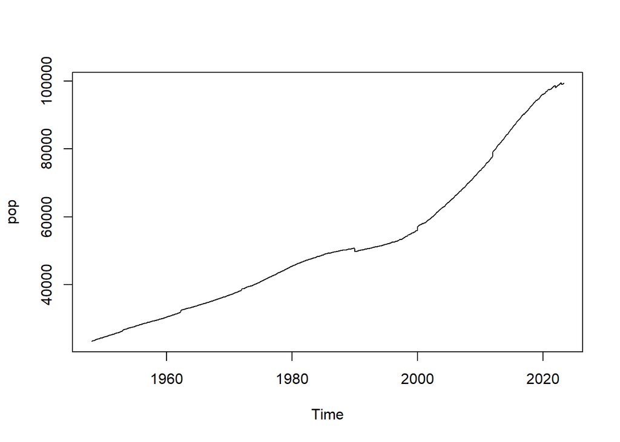

```r
options(scipen=5)
plot(pop)
```

Na wykresie widać, że wielkość populacji ludzi w wieku powyżej 55 roku życia (włącznie) niemalże ciągle rośnie. Obserwowalny jest m.in. niewielki spadek pomiędzy 1980 i 2000 rokiem.

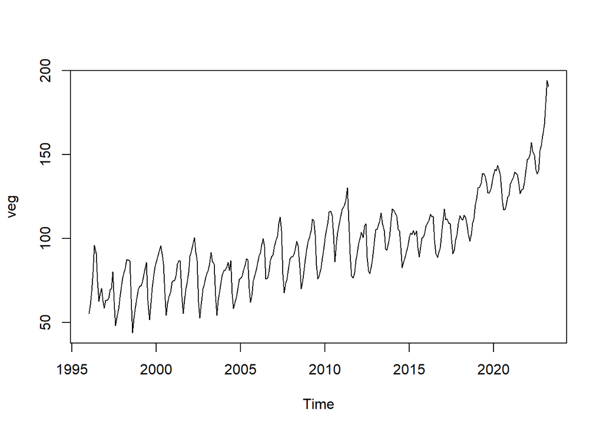

```r
plot(veg)
```

Wykres indeksu cen warzyw w Polsce charakteryzuje się trendem rosnącym oraz wyraźną sezonowością. Ceny warzyw zmieniają się w każdym roku zależnie od miesiąca; jest to przecież produkt sezonowy, nie produkowany przez okrągły rok. Zbiory odbywają się w określonych porach roku i właśnie wtedy warzywa są najtańsze.

## b. wykresy sezonowe

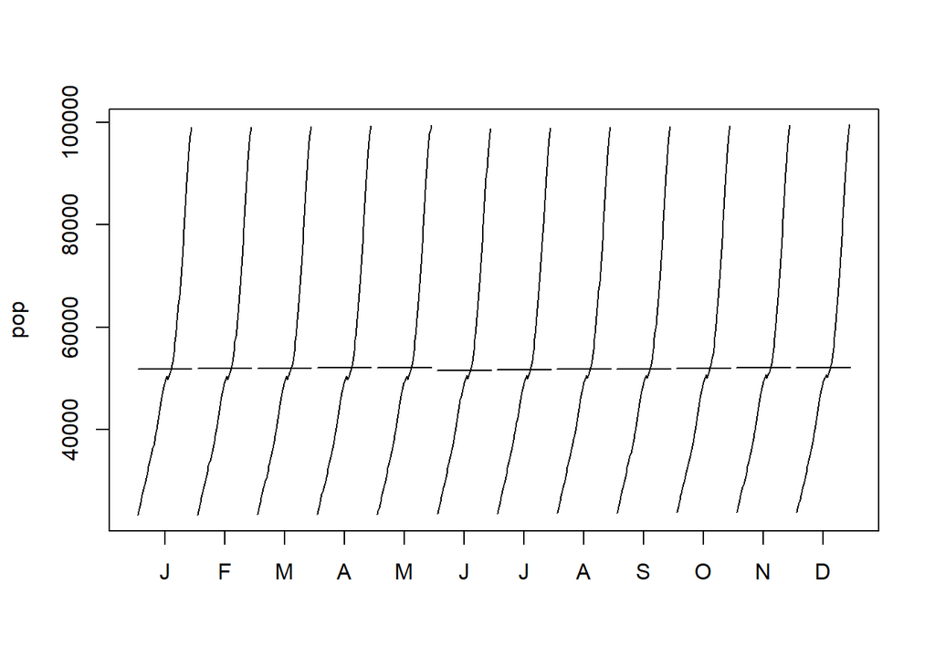

```r
monthplot(pop)
```

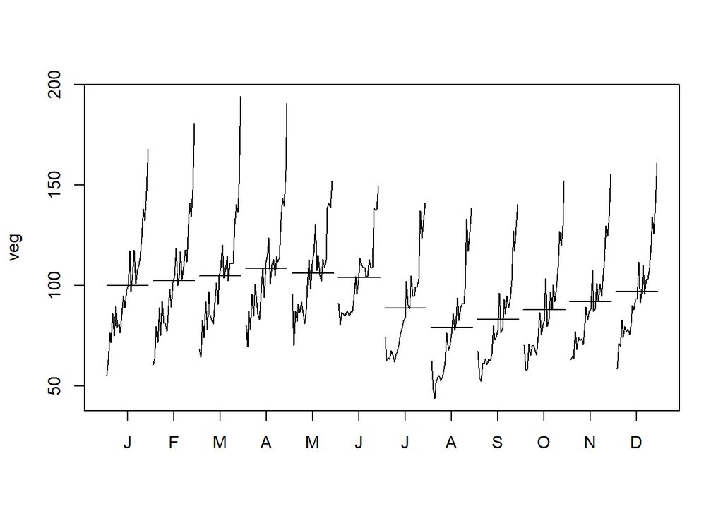

```r
monthplot(veg)
```

Wykres monthplot dla szeregu czasowego dotyczącego populacji ukazuje trend wzrostowy w każdym miesiącu. Z kolei wykres szeregu dla danych dotyczących cen warzyw przedstawia zarówno sezonowość, jak i trend wzrostowy. Średnia cen jest najwyższa w kwietniu.

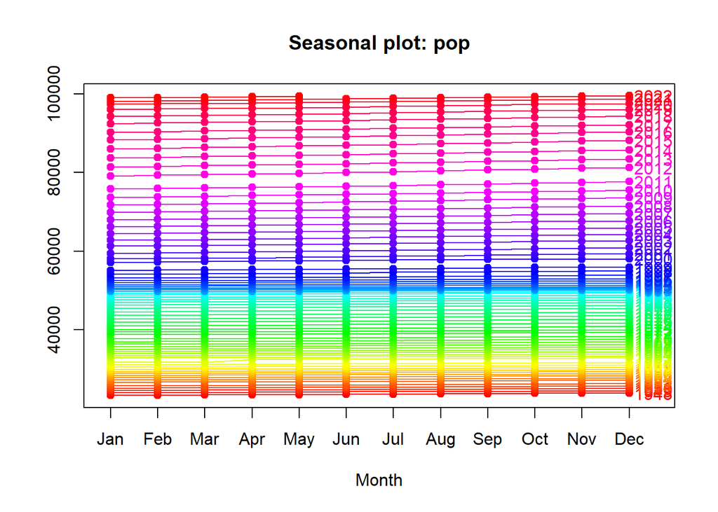

```r
library(forecast)

seasonplot(pop,
           col = rainbow(75),
           year.labels = TRUE,
           pch = 19)
```

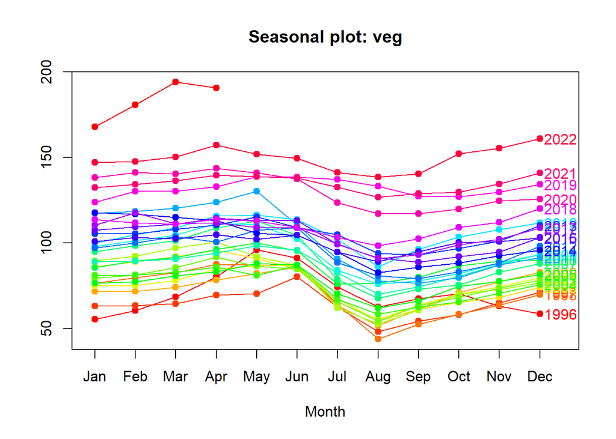

```r
seasonplot(veg,
           col = rainbow(27),
           year.labels = TRUE,
           pch = 19)
```

Funkcja seasonplot z pakietu forecast pozwala na zaprezentowanie danych w rozbiciu na kolejne okresy jednostkowe. Forma taka pomaga analizować i zauważać zarówno sezonowość okresów jak i odstępstwom od wzorca sezonowości w poszczególnych okresach (np. jednostkowe, nietypowe zachowanie w konkretnym roku).

Seasonal plot dla szeregu “pop” przedstawia kolorowe, wręcz symetryczne względem siebie linie, czyli trend. Dla szeregu “veg” widać natomiast, że ceny warzyw zazwyczaj są najniższe w sierpniu. Następnie zaczynają powoli rosnąć, by zacząć się wyraźnie obniżać w okolicach czerwca.

## c. wykresy pudełkowe

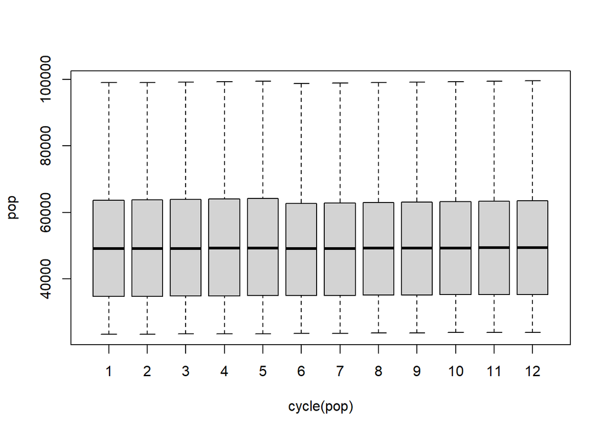

```r
boxplot(pop ~ cycle(pop))
```

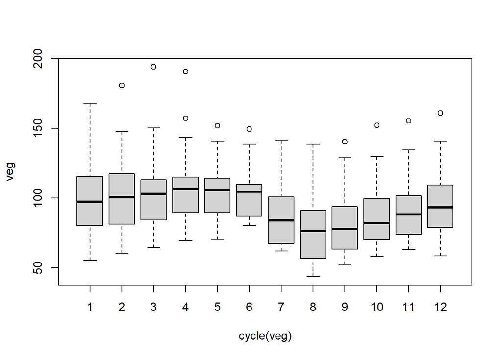

```r
boxplot(veg ~ cycle(veg))
```

Wykres typu boxplot dostarcza nam syntetycznych informacji na temat zmienności szeregów dla poszczególnych okresów. Na wykresie mamy mediany, kwartyle(brzegi pudełek), wartości minimalne i maksymalne(wąsy) oraz wartości odstające (kropki)

Wykres pudełkowy potwierdza wniosek postawiony wcześniej, że w przypadku szerego “pop” średnia z każdego miesiąca utrzymuje się na bardzo zbliżonym poziomie.

Z kolei boxplot dla szeregu “veg” dowodzi, że średnia cena faktycznie osiąga najniższą wartość w sierpniu. Choć najwyższy “wąs” dotyczy stycznia, to jednak najwyższa średnia cen jest obserwowana w kwietniu.

## d. wykresy rozrzutu dla wartości opóźnionych

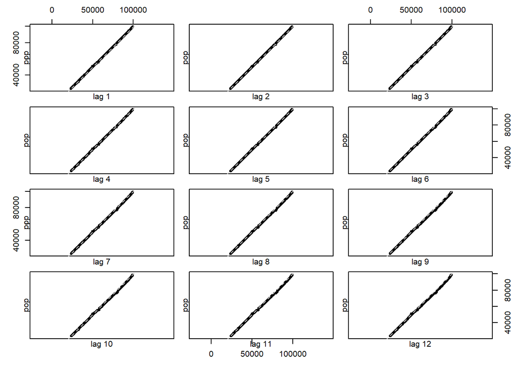

```r
lag.plot(pop, lags=12, do.lines=FALSE)
```

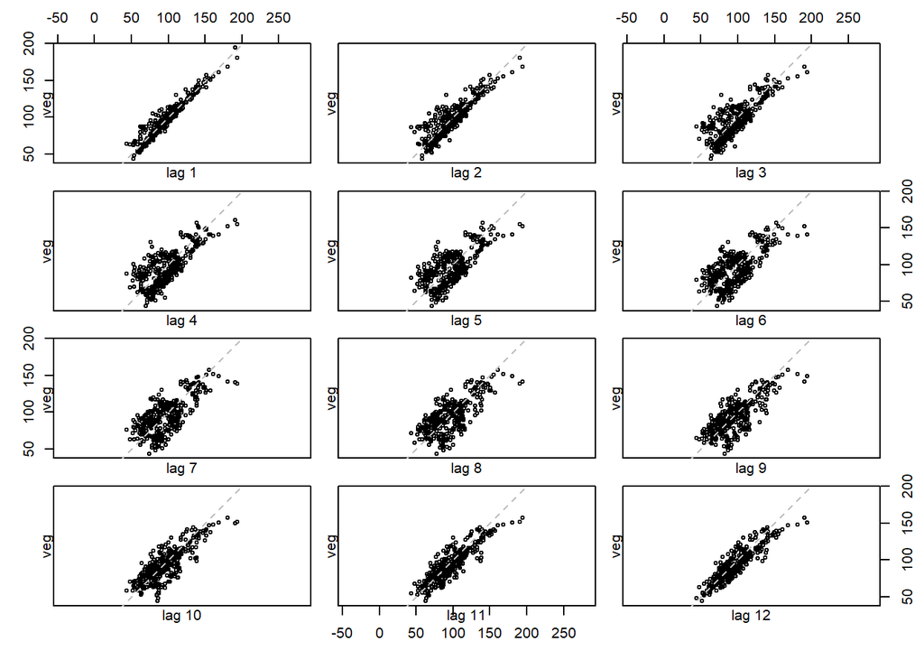

```r
lag.plot(veg, lags=12, do.lines=FALSE)
```

Wykres rozrzutu jest podstawowym narzędziem graficznym wykorzystywanym do badania zależności dwóch zmiennych w klasycznej analizie danych. Na wykresach rozrzutu dla wartości opóźnionych przedstawiamy zależność wartości szeregu od wartości przesuniętych o opóźnienie lag - rysujemy pary (X(t), X(t-lag)) dla kolejnych chwil t. Jeżeli punkty na wykresie przedstawiają jednorodną chmurę punktów, bez jakiejkolwiek struktury, świadczy to o braku istotnej zależności czasowej pomiędzy wartościami szeregu przesuniętymi o konkretne opóźnienie.

Wykres rozrzutu dla pierwszego szeregu wskazuje na silną korelację danych dla opóźnień każdym krokiem.

Dla szeregu veg zauważalna jest korelacja dla lag=1, oznacza to, że obecne wartości szeregu czasowego są skorelowane z wartościami opóźnionymi o jedną jednostkę czasu. To może wskazywać na autokorelację autoregresyjną (AR) rzędu 1, co oznacza, że bieżące wartości są zależne od wartości jednej poprzedniej obserwacji.

Mocna korelacja występuje też dla lag=12, co może wskazywać na obecność rocznej sezonowości.

## e. wykresy autokorelacji ACF

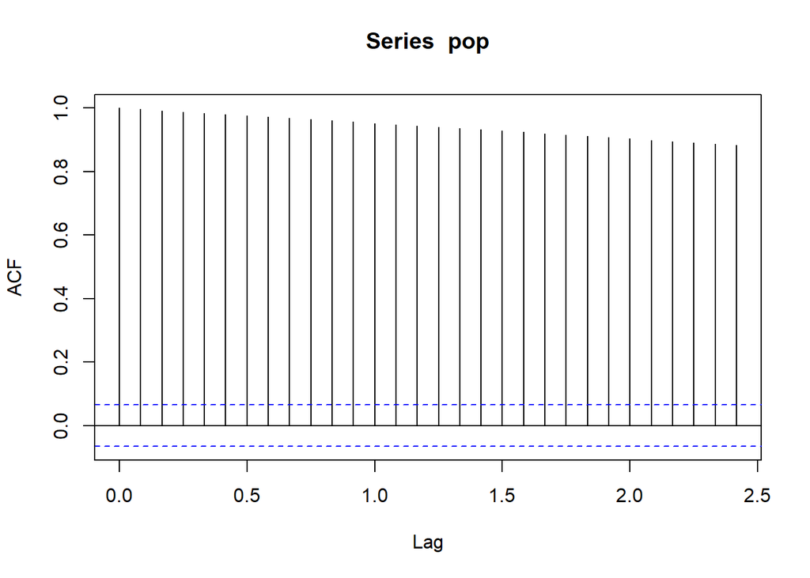

```r
acf(pop)
```

Dodatnie i powoli zanikające wartości ACF sugerują, że dane zawierają deterministyczną składową trendu.

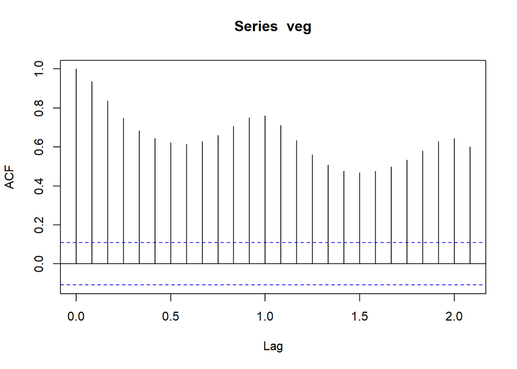

```r
acf(veg)
```

ACF zanikające bardzo powoli i cyklicznie wskazuje na obecność trendu sezonowego.

## f. wykresy cząstkowej korelacji PACF

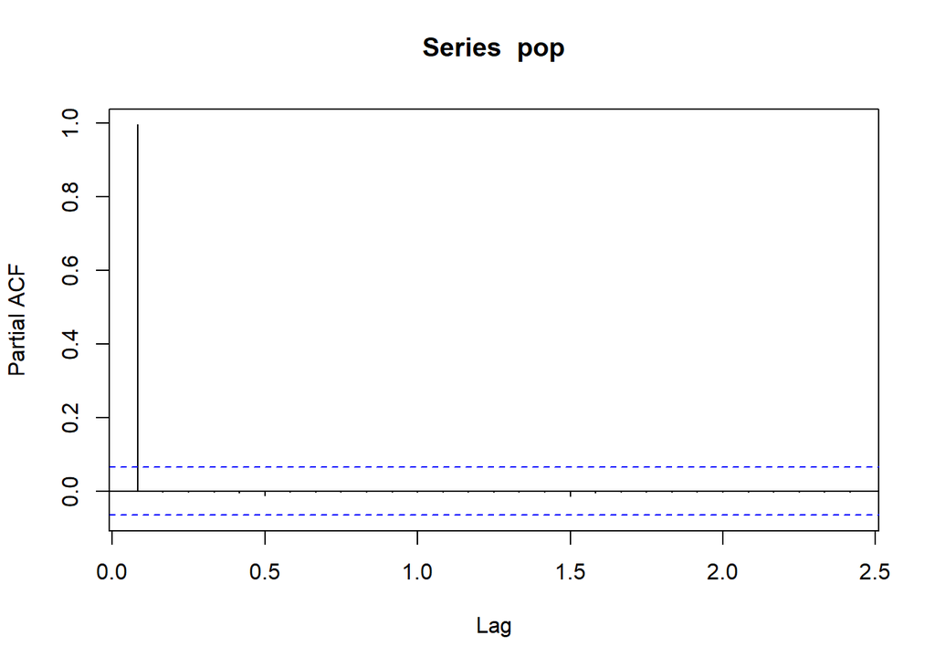

```r
pacf(pop)
```

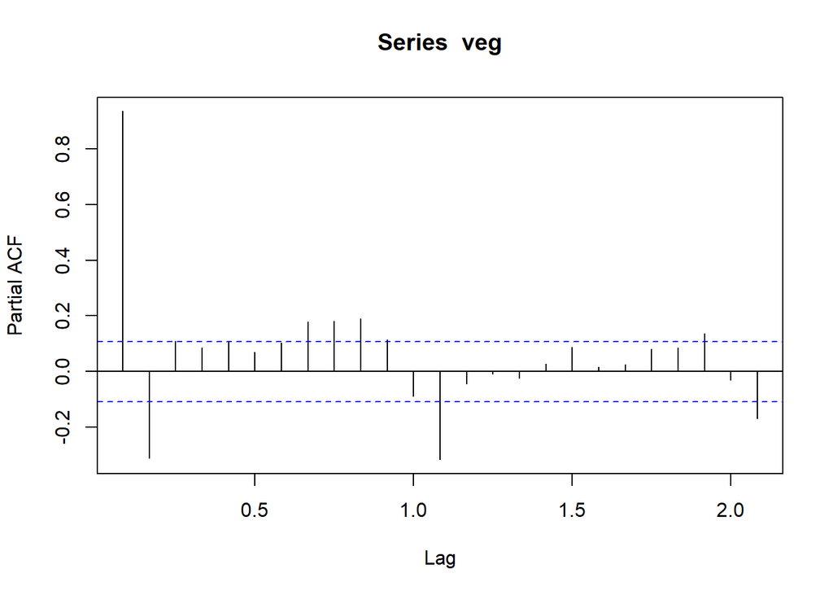

```r
pacf(veg)
```

# Dekompozycja

## a. dekompozycja addytywna szeregu z trendem

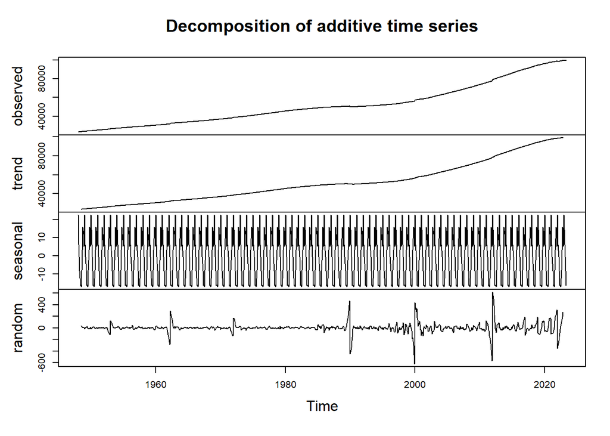

```r
dpop <- decompose(pop, type = "additive")
plot(dpop)
```

## b. dekompozycja multiplikatywna szeregu z trendem

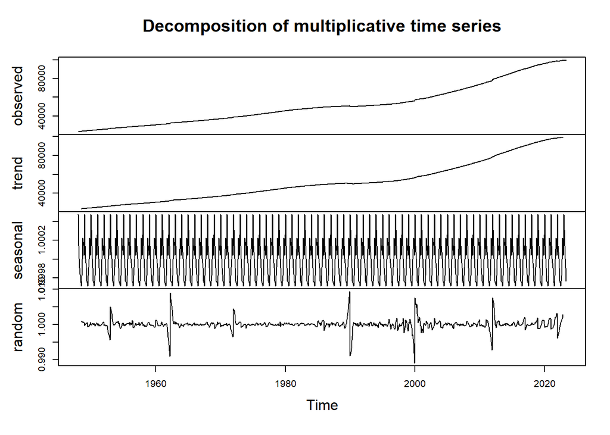

```r
dpop1 <- decompose(pop, type = "multiplicative")
plot(dpop1)
```

## c. dekompozycja addytywna szeregu z sezonowością

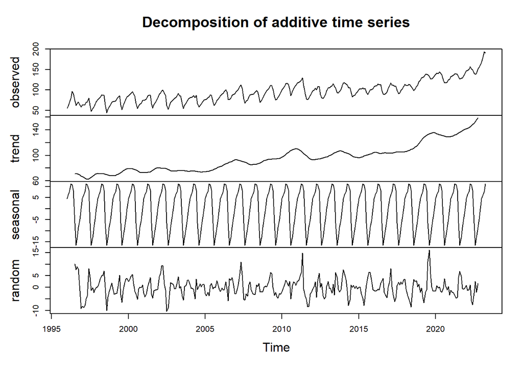

```r
dveg <- decompose(veg, type = "additive")
plot(dveg)
```

## d. dekompozycja multiplikatywna szeregu z sezonowością

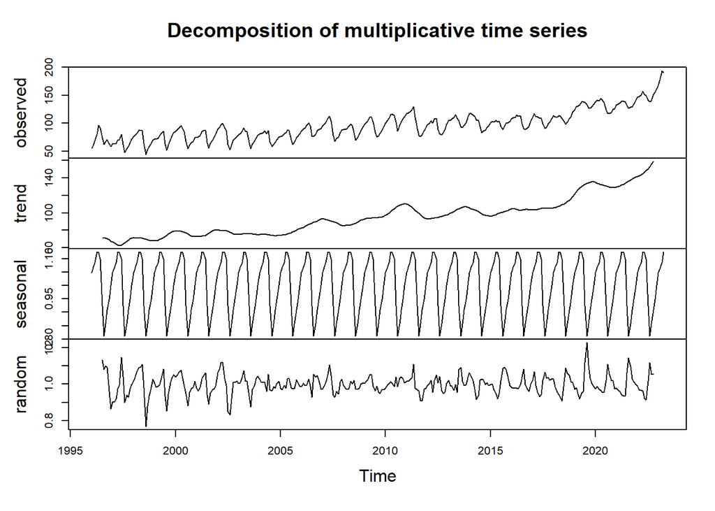

```r
dveg1 <- decompose(veg, type = "multiplicative")
plot(dveg1)
```

Wykres random w przypadku dekompozycji addytywnej osiąga inny przedział wartości - nawet wartości ujemne. Za to po dekompozycji multiplikatywnej wykres znajduje się “wyżej” na osi Y.

## e. dekompozycja za pomocą ruchomej średniej szeregu z trendem

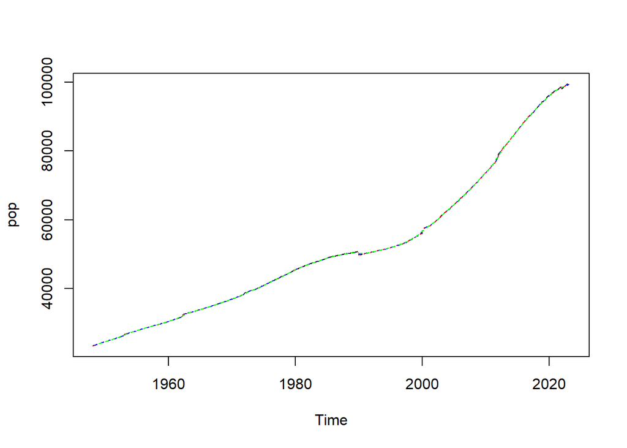

```r
ts1ma1 <- filter(pop, sides=2, filter=rep(1/3,3))
ts1ma2 <- filter(pop, sides=2, filter=rep(1/7,7))
ts1ma3 <- filter(pop, sides=2, filter=rep(1/25,25))
plot(pop, col="black", lty=2)
lines(ts1ma1, col="red", lty=2)
lines(ts1ma2, col="blue", lty=2)
lines(ts1ma3, col="green", lty=2)
```

Kolorowe linie leżą niemalże na oryginalnym wykresie szeregu czasowego “pop” - od początku był on już dość gładki.

## f. dekompozycja za pomocą ruchomej średniej szeregu z sezonowością

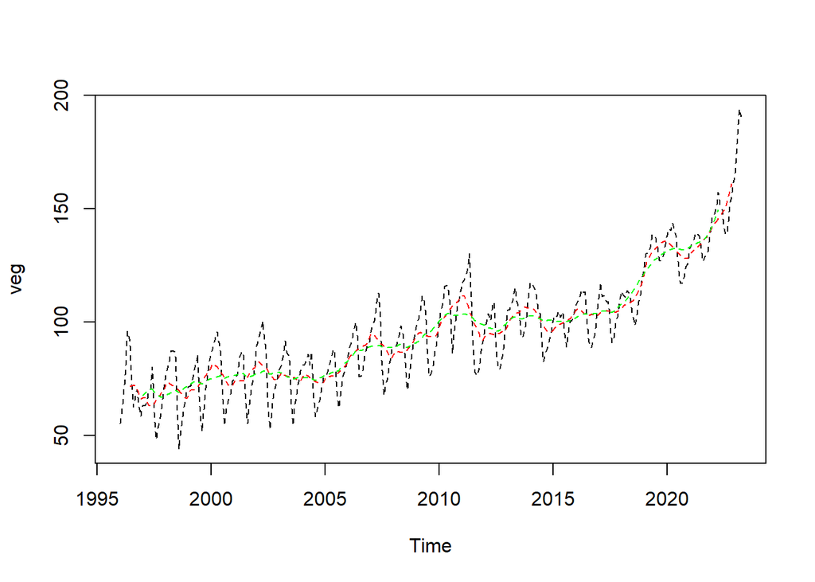

```r
ts1ma11 <- filter(veg, sides=2, filter=rep(1/11,11))
ts1ma22 <- filter(veg, sides=2, filter=rep(1/20,20))
ts1ma33 <- filter(veg, sides=2, filter=rep(1/25,25))

plot(veg, col="black", lty=2)
lines(ts1ma11, col="red", lty=2)
#lines(ts1ma22, col="blue", lty=2)
lines(ts1ma33, col="green", lty=2)
```

Można zauważyć, że im większa wartość x w funkcji rep(1/x,x), tymbardziej linie stają się wygładzone.

## g. dekompozycja wielomianowa szeregu z trendem

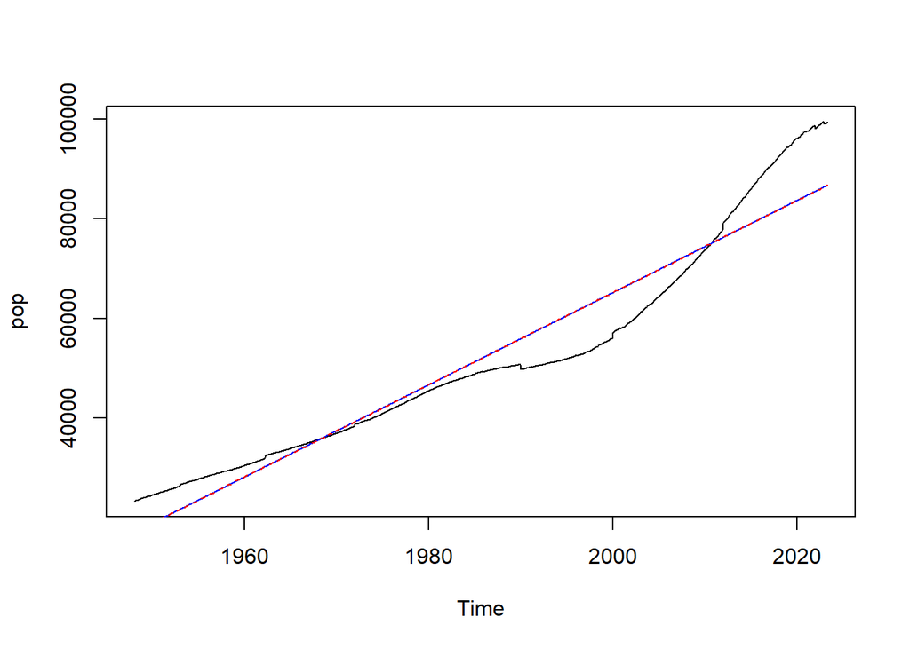

```r
pop_poly1 <- tslm(pop~trend)
pop_poly2 <- tslm(pop ~ trend + season)

plot(pop)
lines(fitted(pop_poly1), col = "blue", lty = 1)
lines(fitted(pop_poly2), col = "red", lty = 2)
```

Kolorowe linie nachodzą na siebie, ukazując wyraźny trend wzrostowy bez trendu sezonowego.

## h. dekompozycja wielomianowa szeregu z sezonowością

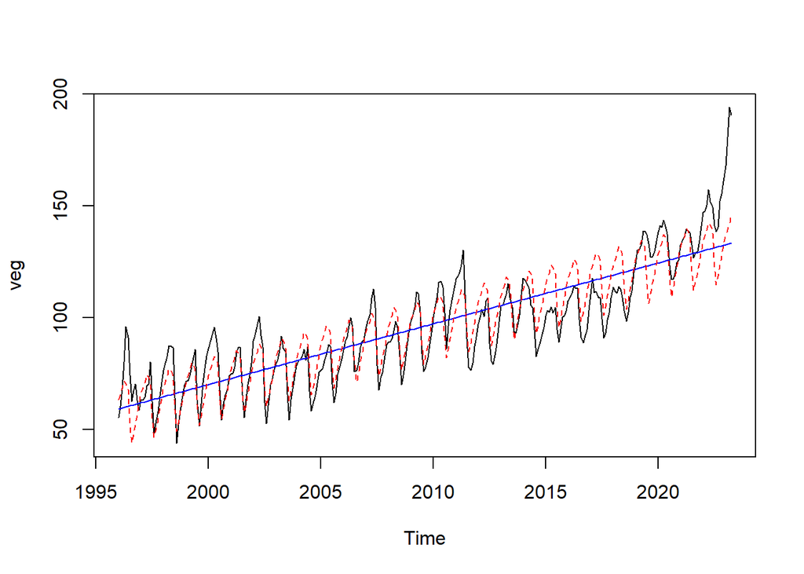

```r
veg_poly1 <- tslm(veg~trend)
veg_poly2 <- tslm(veg ~ trend + season)

plot(veg)
lines(fitted(veg_poly1), col = "blue", lty = 1)
lines(fitted(veg_poly2), col = "red", lty = 2)
```

Niebieska linia na wykresie wskazuje na trend wzrostowy. Czerwona linia świadczy zać o występowaniu sezonowości.

# Eliminacja trendu i sezonowości

## Na szeregach powstałych po dekompozycji addytywnej

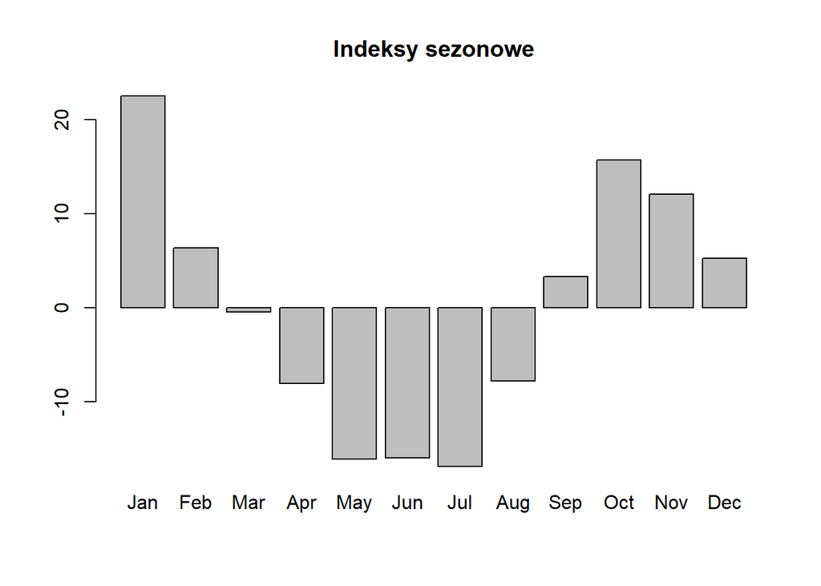

```r
dpop.trend <- dpop$trend
dpop.sezonowosc <- dpop$seasonal
dpop.indeksy <- dpop$figure
dpop.reszty <- dpop$random
barplot(dpop.indeksy, names.arg = month.abb, main="Indeksy sezonowe")
```

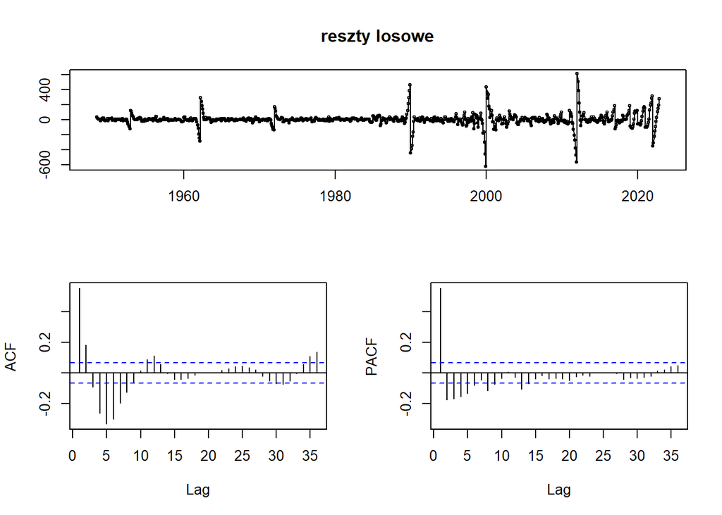

```r
tsdisplay(dpop.reszty, main="reszty losowe")
```

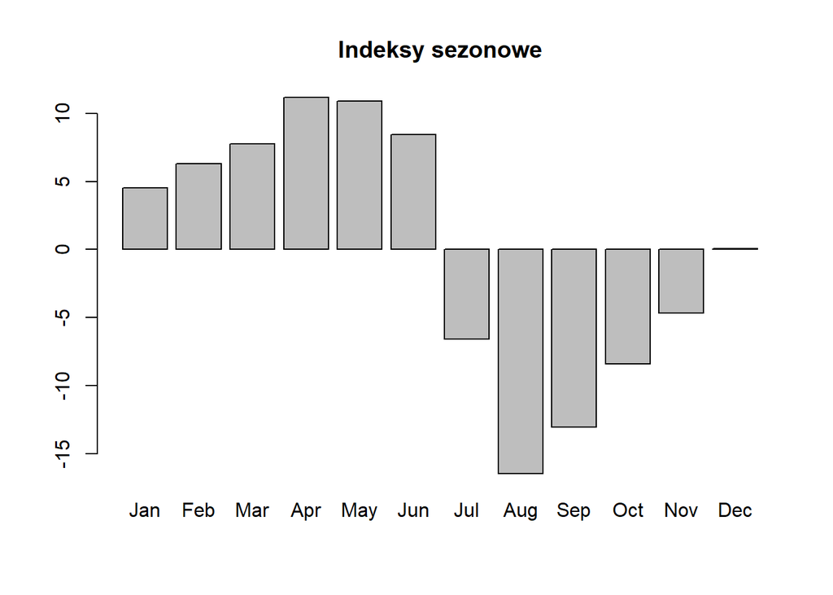

```r
dveg.trend <- dveg$trend
dveg.sezonowosc <- dveg$seasonal
dveg.indeksy <- dveg$figure
dveg.reszty <- dveg$random
barplot(dveg.indeksy, names.arg = month.abb, main="Indeksy sezonowe")
```

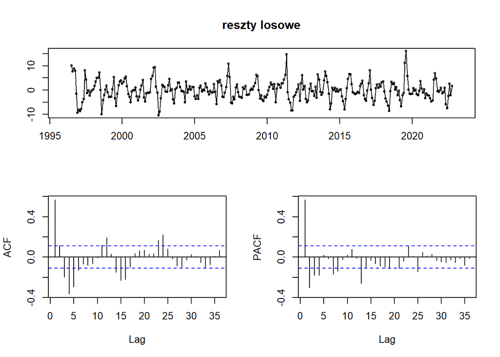

```r
tsdisplay(dveg.reszty, main="reszty losowe")
```

## Odsezonowanie szeregu veg

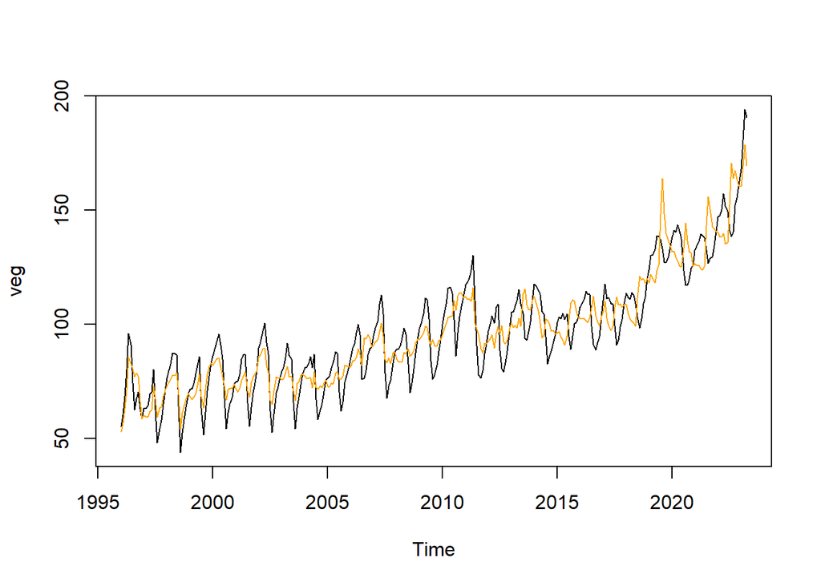

```r
dveg1 <- decompose(veg, type = "multiplicative")
dveg2 <- seasadj(dveg1)
plot(veg)
lines(dveg2, col="orange", lty=1)
```

# Uczynienie szeregów stacjonarnymi

W tym celu przeprowadziłam różnicowanie na szeregach pierwotnych z pomocą funkcji diff:

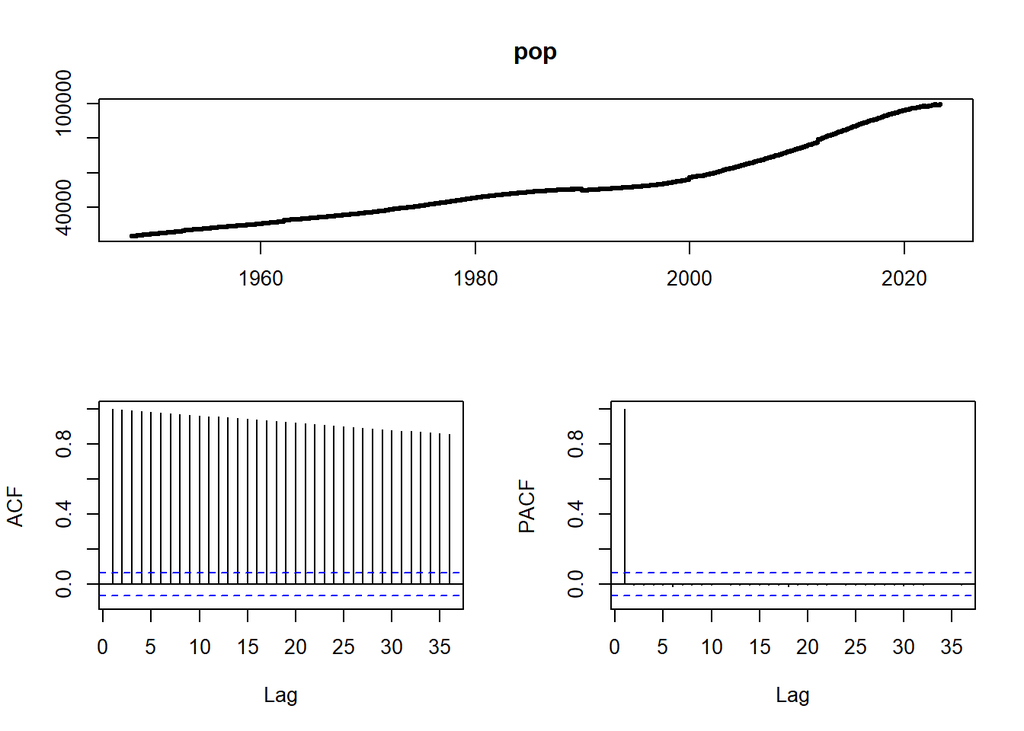

```r
#Przed
tsdisplay(pop)
```

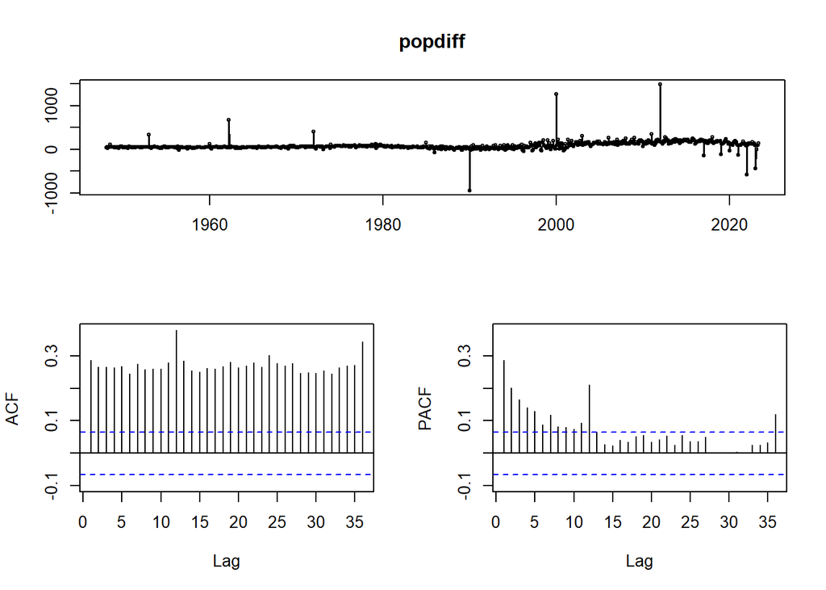

```r
#Po
popdiff <- diff(pop)
tsdisplay(popdiff)
```

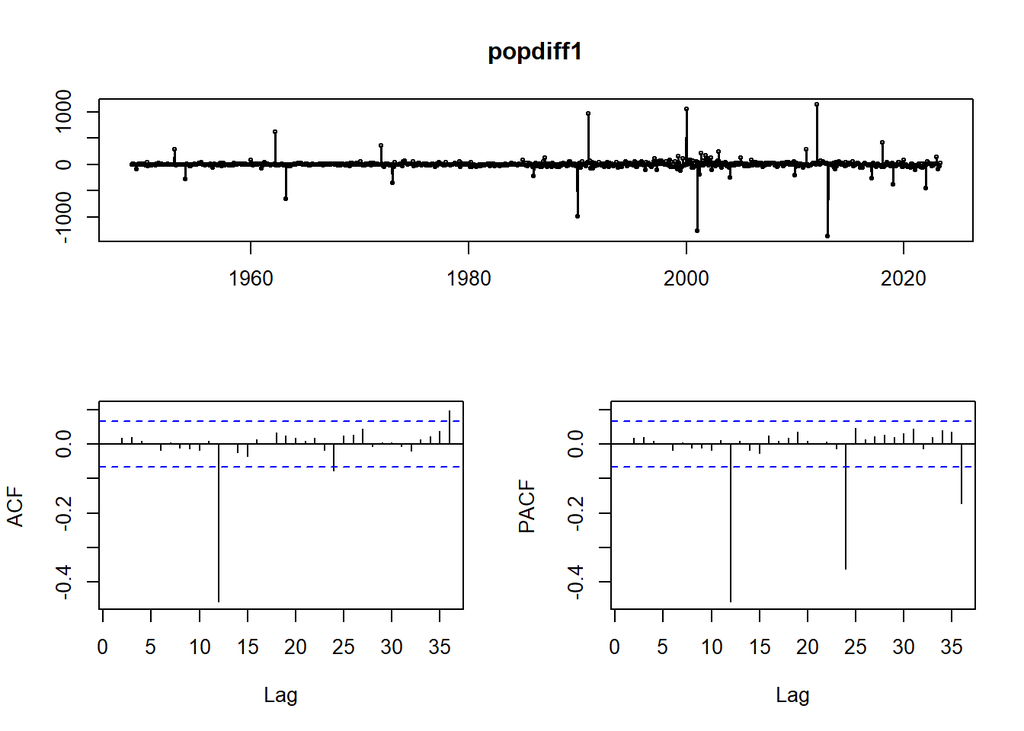

```r
popdiff1 <- diff(popdiff, lag=12)
tsdisplay(popdiff1)
```

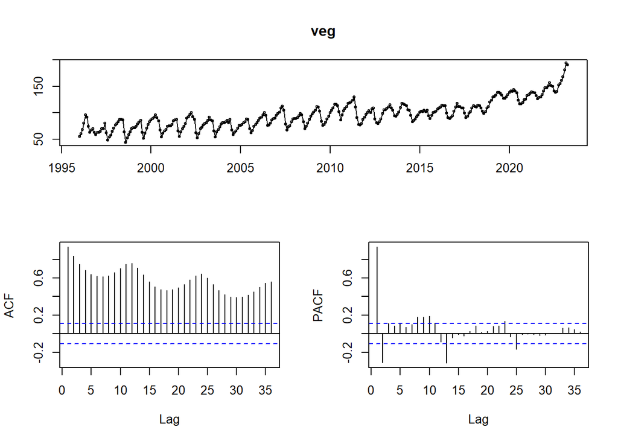

```r
#Przed
tsdisplay(veg)
```

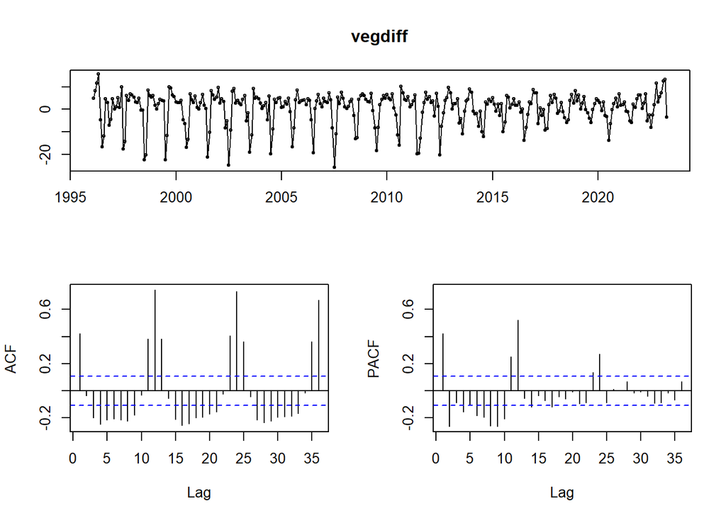

```r
#Po
vegdiff <- diff(veg)
tsdisplay(vegdiff)
```

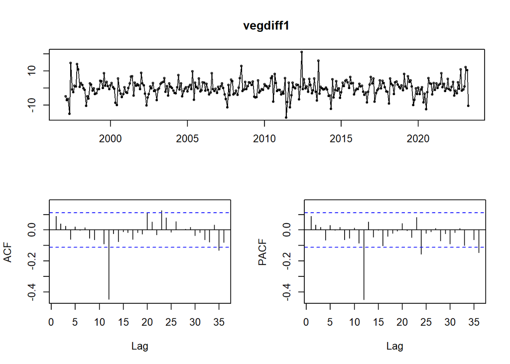

```r
vegdiff1 <- diff(vegdiff, lag=12)
tsdisplay(vegdiff1)
```

W celu sprawdzenia stacjonarności szeregu czasowego, przeprowadziłam test Kwiatkowskiego-Phillipsa-Schmidta (KPSS).

Hipoteza zerowa (H0): Szereg czasowy jest stacjonarny.  
Hipoteza alternatywna (HA): Szereg czasowy nie jest stacjonarny.

```r
library(tseries)
kpss.test(popdiff1)
```

```
##
##  KPSS Test for Level Stationarity
##
## data:  popdiff1
## KPSS Level = 0.045352, Truncation lag parameter = 6, p-value = 0.1
```

```r
kpss.test(vegdiff1)
```

```
##
##  KPSS Test for Level Stationarity
##
## data:  vegdiff1
## KPSS Level = 0.050045, Truncation lag parameter = 5, p-value = 0.1
```

W obu przypadkach P-value dla testu KPSS wynosi 0.1, czyli jest większa od poziomu istotności 0.05. To oznacza, że nie ma wystarczających dowodów, aby odrzucić hipotezę zerową (H0) o stacjonarności poziomu szeregu czasowego.

Na podstawie powyższych wyników można wnioskować, że nie ma istotnych dowodów na niestacjonarność szeregów czasowych popdiff1 i vegdiff1.

# Sprawdzenie, czy szeregi są realizacją szumu białego

Symulacja szumu białego:

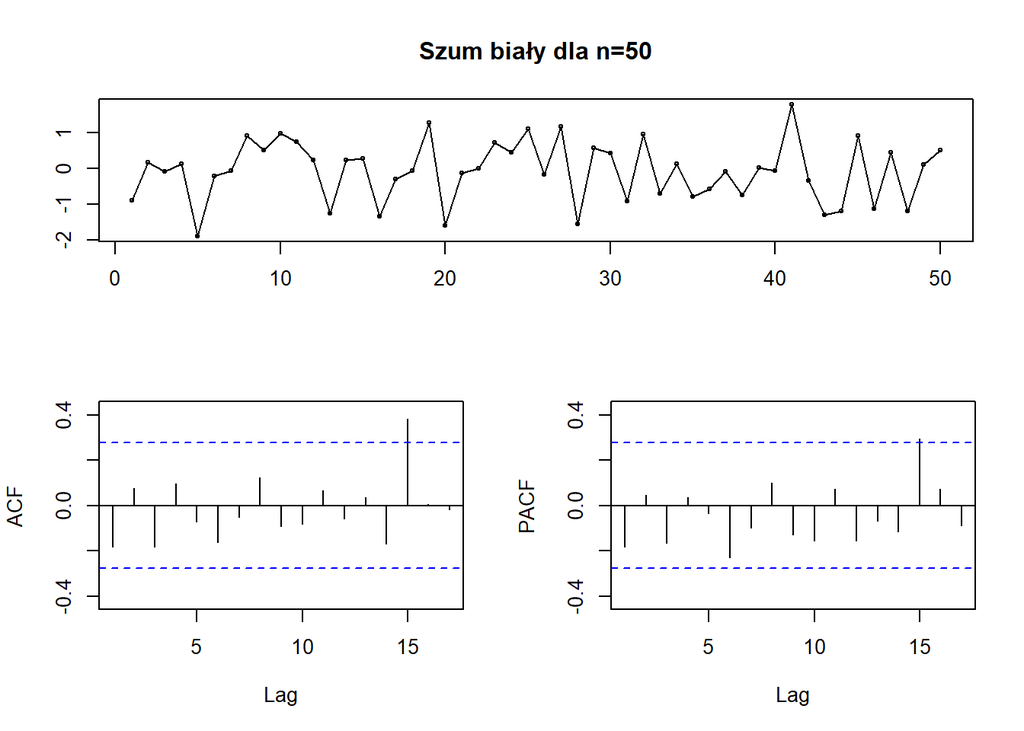

```r
SB2 <- rnorm(n=50)
SB2 <- as.ts(SB2)
tsdisplay(SB2, main="Szum biały dla n=50")
```

Szereg możemy uznać za realizację białego szumu jeżeli:  
i) co najmniej 95% autokorelacji próbkowych (ACF(h), h=1,2,.., hmax) znajduje się w przedziale ufności  
ii) nie ma autokorelacji „istotnie ” wychodzących poza przedział ufności

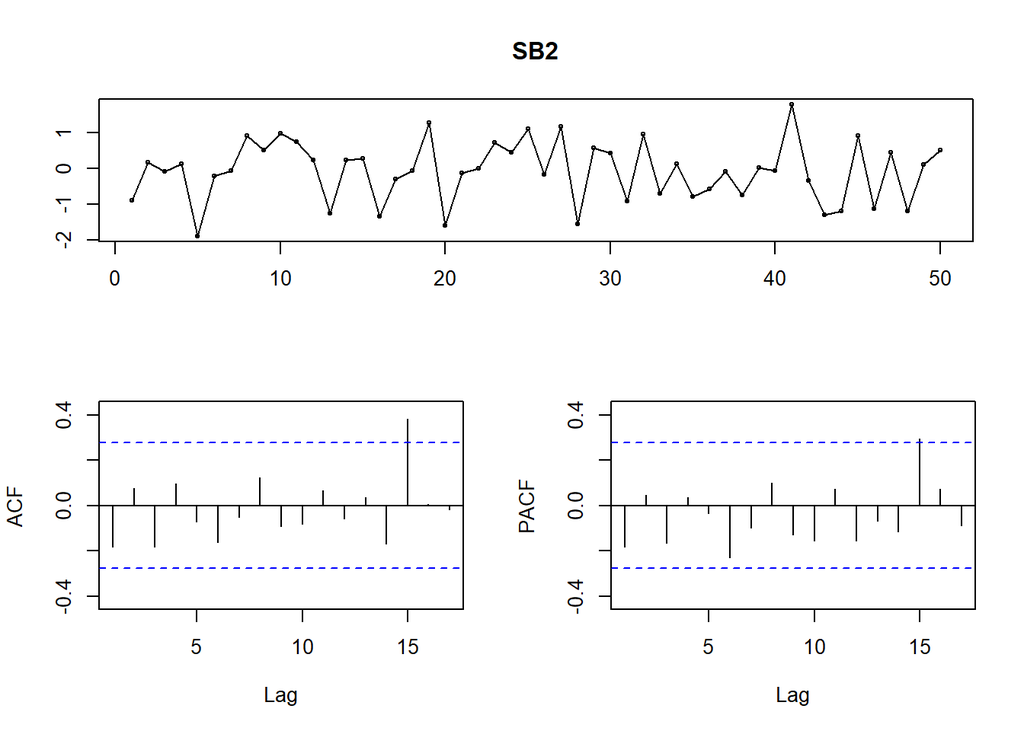

```r
tsdisplay(SB2)
```

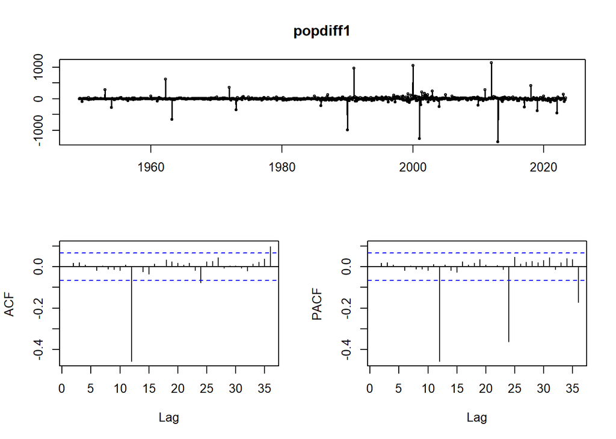

```r
tsdisplay(popdiff1)
```

Szereg popdiff1 (czyli pop po wyeliminowaniu trendu i sezonowości) nie jest realizacją szumu białego ponieważ wartości korelacji wystają poza przedziały ufności.

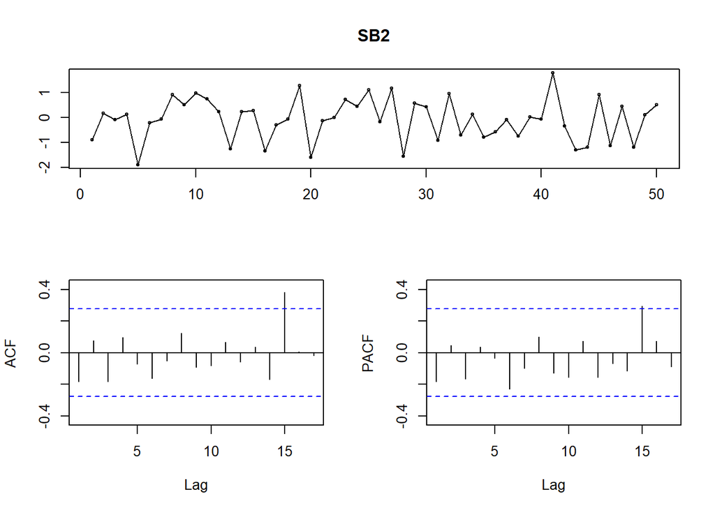

```r
tsdisplay(SB2)
```

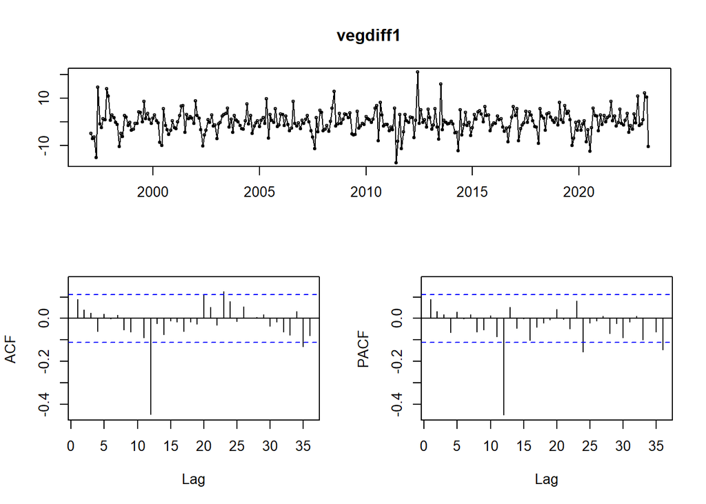

```r
tsdisplay(vegdiff1)
```

Szereg vegdiff1 (czyli veg po wyeliminowaniu trendu i sezonowości) nie jest realizacją szumu białego ponieważ wartości korelacji są dość duże i wystają poza przedziały ufności.

Dla szeregu popdiff1 warto brać pod uwagę modele AR(36), AR(24) i AR(12) oraz MA(36), MA(24), MA(12).

Dla szeregu vegdiff1 warto brać pod uwagę modele AR(36), AR(24) i AR(12) oraz MA(35), MA(23), MA(12).

# Metody estymacji

## Dopasowanie modelu AR dla szeregu popdiff1:

1. Metoda Yule-Walkera

```r
popdiff1.yw <- ar(popdiff1, aic=FALSE, order.max=36, method=c("yule-walker"))
popdiff1.yw
```

```
##
## Call:
## ar(x = popdiff1, aic = FALSE, order.max = 36, method = c("yule-walker"))
##
## Coefficients:
##       1        2        3        4        5        6        7        8
##  0.0224   0.0110   0.0070   0.0226   0.0319   0.0005   0.0415   0.0009
##       9       10       11       12       13       14       15       16
## -0.0089   0.0022   0.0276  -0.6867   0.0380  -0.0114  -0.0184   0.0387
##      17       18       19       20       21       22       23       24
##  0.0362   0.0313   0.0714   0.0122   0.0078   0.0269   0.0166  -0.4719
##      25       26       27       28       29       30       31       32
##  0.0488   0.0090   0.0167   0.0244   0.0239   0.0279   0.0468  -0.0105
##      33       34       35       36
##  0.0197   0.0398   0.0374  -0.1731
##
## Order selected 36  sigma^2 estimated as  8280
```

2. Metoda największej wiarygodności (MLE-Maksimum Likelihood Estimation)

```r
popdiff1.mle <- ar(popdiff1, aic=FALSE, order.max=36, method=c("mle"))
popdiff1.mle
```

```
##
## Call:
## ar(x = popdiff1, aic = FALSE, order.max = 36, method = c("mle"))
##
## Coefficients:
##       1        2        3        4        5        6        7        8
##  0.0223   0.0118   0.0075   0.0225   0.0324   0.0006   0.0415   0.0012
##       9       10       11       12       13       14       15       16
## -0.0081   0.0026   0.0261  -0.6833   0.0375  -0.0102  -0.0172   0.0378
##      17       18       19       20       21       22       23       24
##  0.0367   0.0307   0.0709   0.0111   0.0089   0.0295   0.0158  -0.4718
##      25       26       27       28       29       30       31       32
##  0.0461   0.0093   0.0165   0.0240   0.0240   0.0267   0.0462  -0.0114
##      33       34       35       36
##  0.0197   0.0413   0.0368  -0.1744
##
## Order selected 36  sigma^2 estimated as  7902
```

3. Automatyczny dobór: (aic=TRUE)

```r
popdiff1.aic <- ar(popdiff1, aic=TRUE)
popdiff1.aic
```

```
##
## Call:
## ar(x = popdiff1, aic = TRUE)
##
## Coefficients:
##       1        2        3        4        5        6        7        8
##  0.0048   0.0034   0.0008   0.0201   0.0219  -0.0102   0.0251   0.0055
##       9       10       11       12       13       14       15       16
## -0.0142  -0.0118   0.0087  -0.6214   0.0108  -0.0195  -0.0294   0.0234
##      17       18       19       20       21       22       23       24
##  0.0163   0.0119   0.0395   0.0151   0.0003   0.0069  -0.0092  -0.3627
##
## Order selected 24  sigma^2 estimated as  8504
```

## Dopasowanie modelu AR dla szeregu vegdiff1:

1. Metoda Yule-Walkera

```r
vegdiff1.yw <- ar(vegdiff1, aic=FALSE, order.max=36, method=c("yule-walker"))
vegdiff1.yw
```

```
##
## Call:
## ar(x = vegdiff1, aic = FALSE, order.max = 36, method = c("yule-walker"))
##
## Coefficients:
##       1        2        3        4        5        6        7        8
##  0.0739  -0.0035  -0.0257  -0.1361   0.0028  -0.0408   0.0194  -0.1072
##       9       10       11       12       13       14       15       16
## -0.0463  -0.0019  -0.0222  -0.5479   0.0355  -0.0811  -0.0002  -0.1468
##      17       18       19       20       21       22       23       24
## -0.0669  -0.0881  -0.0313   0.0015  -0.0629  -0.0696   0.0672  -0.2414
##      25       26       27       28       29       30       31       32
## -0.0351  -0.0224  -0.0011  -0.0760  -0.0271  -0.0911  -0.0230  -0.0018
##      33       34       35       36
## -0.1022   0.0083  -0.0498  -0.1463
##
## Order selected 36  sigma^2 estimated as  18.09
```

2. Metoda największej wiarygodności (MLE-Maksimum Likelihood Estimation)

```r
vegdiff1.mle <- ar(vegdiff1, aic=FALSE, order.max=36, method=c("mle"))
vegdiff1.mle
```

```
##
## Call:
## ar(x = vegdiff1, aic = FALSE, order.max = 36, method = c("mle"))
##
## Coefficients:
##       1        2        3        4        5        6        7        8
##  0.0199  -0.0127  -0.0473  -0.1663  -0.0028  -0.0283  -0.0135  -0.1375
##       9       10       11       12       13       14       15       16
## -0.0588   0.0119  -0.0467  -0.7434  -0.0370  -0.1039  -0.0255  -0.2289
##      17       18       19       20       21       22       23       24
## -0.1481  -0.1027  -0.0428  -0.0124  -0.1023  -0.0863   0.0318  -0.4062
##      25       26       27       28       29       30       31       32
## -0.0918  -0.0474  -0.0376  -0.1256  -0.1003  -0.1256  -0.0416  -0.0115
##      33       34       35       36
## -0.1512  -0.0301  -0.0905  -0.2384
##
## Order selected 36  sigma^2 estimated as  13.26
```

3. Automatyczny dobór: (aic=TRUE)

```r
vegdiff1.aic <- ar(vegdiff1, aic=TRUE)
vegdiff1.aic
```

```
##
## Call:
## ar(x = vegdiff1, aic = TRUE)
##
## Coefficients:
##       1        2        3        4        5        6        7        8
##  0.0512   0.0385  -0.0004  -0.0939   0.0365   0.0046   0.0316  -0.0860
##       9       10       11       12
## -0.0402   0.0334  -0.0437  -0.4493
##
## Order selected 12  sigma^2 estimated as  18.44
```

Automatyczny dobór jest zbliżony do metody Yule-Walkera. Automatyczny dobór w obu przypadkach dobrał modele rzędu niższego niż ten dobrany przed dwie pozostałe metody.

# Wyznaczenie współczynników dla modelu MA(q)

```r
popdiff1_arima36 <- arima(popdiff1, order=c(0,0,36))
summary(popdiff1_arima36)
```

```
##
## Call:
## arima(x = popdiff1, order = c(0, 0, 36))
##
## Coefficients:
##          ma1     ma2     ma3     ma4     ma5      ma6     ma7     ma8     ma9
##       0.0399  0.0172  0.0309  0.0294  0.0208  -0.0052  0.0278  0.0107  0.0136
## s.e.  0.0343  0.0340  0.0343  0.0341  0.0346   0.0352  0.0345  0.0345  0.0344
##         ma10    ma11     ma12    ma13     ma14     ma15    ma16     ma17
##       0.0062  0.0408  -0.7834  0.0280  -0.0113  -0.0041  0.0122  -0.0131
## s.e.  0.0343  0.0344   0.0351  0.0423   0.0428   0.0425  0.0431   0.0419
##         ma18    ma19    ma20    ma21    ma22    ma23     ma24    ma25    ma26
##       0.0343  0.0141  0.0275  0.0433  0.0322  0.0006  -0.0778  0.0364  0.0426
## s.e.  0.0414  0.0428  0.0421  0.0430  0.0419  0.0441   0.0442  0.0345  0.0363
##         ma27    ma28     ma29     ma30     ma31    ma32    ma33    ma34    ma35
##       0.0847  0.0217  -0.0117  -0.0159  -0.0373  0.0057  0.0359  0.0023  0.0498
## s.e.  0.0342  0.0361   0.0337   0.0353   0.0346  0.0364  0.0349  0.0361  0.0352
##         ma36  intercept
##       0.0521     0.0561
## s.e.  0.0357     2.2945
##
## sigma^2 estimated as 7322:  log likelihood = -5247.74,  aic = 10571.49
##
## Training set error measures:
##                       ME     RMSE      MAE MPE MAPE      MASE         ACF1
## Training set -0.05009185 85.56642 29.83084 NaN  Inf 0.5546942 0.0003060691
```

```r
popdiff1_arima24 <- arima(popdiff1, order=c(0,0,24))
summary(popdiff1_arima24)
```

```
##
## Call:
## arima(x = popdiff1, order = c(0, 0, 24))
##
## Coefficients:
##          ma1     ma2     ma3     ma4     ma5     ma6     ma7     ma8     ma9
##       0.0453  0.0340  0.0347  0.0275  0.0307  0.0032  0.0363  0.0158  0.0136
## s.e.  0.0347  0.0349  0.0355  0.0350  0.0353  0.0376  0.0370  0.0360  0.0362
##         ma10    ma11     ma12    ma13    ma14    ma15    ma16    ma17    ma18
##       0.0129  0.0392  -0.8204  0.0094  0.0184  0.0168  0.0225  0.0177  0.0523
## s.e.  0.0360  0.0362   0.0378  0.0329  0.0332  0.0335  0.0335  0.0337  0.0336
##         ma19    ma20    ma21    ma22    ma23     ma24  intercept
##       0.0268  0.0468  0.0485  0.0494  0.0215  -0.1218     0.2539
## s.e.  0.0354  0.0345  0.0345  0.0348  0.0351   0.0343     1.9640
##
## sigma^2 estimated as 7271:  log likelihood = -5253.96,  aic = 10559.92
##
## Training set error measures:
##                       ME     RMSE    MAE MPE MAPE      MASE          ACF1
## Training set -0.03210467 85.27253 27.952 NaN  Inf 0.5197577 -0.0006893394
```

```r
popdiff1_arima12 <- arima(popdiff1, order=c(0,0,12))
summary(popdiff1_arima12)
```

```
##
## Call:
## arima(x = popdiff1, order = c(0, 0, 12))
##
## Coefficients:
##          ma1     ma2     ma3     ma4     ma5     ma6     ma7     ma8     ma9
##       0.0677  0.0205  0.0480  0.0247  0.0427  0.0105  0.0554  0.0144  0.0404
## s.e.  0.0235  0.0236  0.0236  0.0226  0.0242  0.0267  0.0243  0.0247  0.0246
##         ma10    ma11     ma12  intercept
##       0.0261  0.0543  -0.7874     0.3789
## s.e.  0.0232  0.0238   0.0267     1.8261
##
## sigma^2 estimated as 7588:  log likelihood = -5257.93,  aic = 10543.86
##
## Training set error measures:
##                       ME     RMSE     MAE MPE MAPE      MASE        ACF1
## Training set -0.02731722 87.10712 30.0807 NaN  Inf 0.5593403 -0.02139915
```

```r
vegdiff1_arima35 <- arima(vegdiff1, order=c(0,0,35))
summary(vegdiff1_arima35)
```

```
##
## Call:
## arima(x = vegdiff1, order = c(0, 0, 35))
##
## Coefficients:
##          ma1      ma2      ma3      ma4      ma5      ma6     ma7      ma8
##       0.0639  -0.0318  -0.0895  -0.1858  -0.0377  -0.0011  0.0355  -0.1688
## s.e.  0.0652   0.0660   0.0642   0.0694   0.0680   0.0715  0.0697   0.0668
##           ma9     ma10     ma11     ma12     ma13     ma14    ma15    ma16
##       -0.0918  -0.0233  -0.0936  -0.7972  -0.1186  -0.1558  0.0025  0.1182
## s.e.   0.0621   0.0629   0.0691   0.0725   0.0843   0.0837  0.0823  0.0854
##          ma17    ma18     ma19    ma20    ma21    ma22    ma23    ma24    ma25
##       -0.1045  0.1053  -0.1506  0.4550  0.2067  0.0411  0.1598  0.0738  0.0415
## s.e.   0.0777  0.0872   0.0813  0.0877  0.0964  0.0892  0.0965  0.0688  0.0732
##         ma26     ma27    ma28    ma29    ma30    ma31     ma32     ma33
##       0.3007  -0.0947  0.1064  0.1620  0.0718  0.0688  -0.1912  -0.1466
## s.e.  0.0810   0.0747  0.0706  0.0716  0.0751  0.0722   0.0920   0.0925
##          ma34     ma35  intercept
##       -0.0100  -0.1975     0.0172
## s.e.   0.0904   0.0814     0.0620
##
## sigma^2 estimated as 11.71:  log likelihood = -852.01,  aic = 1778.01
##
## Training set error measures:
##                       ME     RMSE      MAE  MPE MAPE      MASE       ACF1
## Training set 0.009711629 3.421997 2.603942 -Inf  Inf 0.5713352 0.01058323
```

```r
vegdiff1_arima23 <- arima(vegdiff1, order=c(0,0,23))
summary(vegdiff1_arima23)
```

```
##
## Call:
## arima(x = vegdiff1, order = c(0, 0, 23))
##
## Coefficients:
##          ma1     ma2      ma3      ma4      ma5      ma6      ma7      ma8
##       0.0600  0.0397  -0.0684  -0.1697  -0.0352  -0.0061  -0.0085  -0.1547
## s.e.  0.0636  0.0664   0.0723   0.0693   0.0680   0.0825   0.0725   0.0705
##           ma9     ma10     ma11     ma12     ma13     ma14    ma15    ma16
##       -0.1618  -0.0359  -0.0269  -0.8307  -0.1123  -0.0114  0.0395  0.1491
## s.e.   0.0784   0.0625   0.0719   0.0659   0.0637   0.0691  0.0694  0.0793
##          ma17    ma18    ma19    ma20    ma21     ma22    ma23  intercept
##       -0.0143  0.0494  0.0999  0.2791  0.0702  -0.0432  0.0845     0.0341
## s.e.   0.0852  0.0835  0.0902  0.0937  0.0880   0.0820  0.0917     0.0406
##
## sigma^2 estimated as 12.9:  log likelihood = -863.29,  aic = 1776.57
##
## Training set error measures:
##                       ME     RMSE      MAE MPE MAPE      MASE        ACF1
## Training set -0.01261049 3.592201 2.644111 NaN  Inf 0.5801488 0.003233248
```

```r
vegdiff1_arima12 <- arima(vegdiff1, order=c(0,0,12))
summary(vegdiff1_arima12)
```

```
##
## Call:
## arima(x = vegdiff1, order = c(0, 0, 12))
##
## Coefficients:
##          ma1     ma2      ma3      ma4      ma5      ma6      ma7      ma8
##       0.0609  0.0051  -0.0231  -0.1117  -0.0719  -0.0327  -0.0057  -0.0341
## s.e.  0.0480  0.0474   0.0457   0.0435   0.0463   0.0534   0.0479   0.0499
##           ma9     ma10    ma11     ma12  intercept
##       -0.0474  -0.0564  0.0872  -0.7702     0.0303
## s.e.   0.0462   0.0427  0.0483   0.0577     0.0235
##
## sigma^2 estimated as 14.18:  log likelihood = -872.55,  aic = 1773.1
##
## Training set error measures:
##                      ME    RMSE      MAE  MPE MAPE      MASE       ACF1
## Training set -0.1270153 3.76517 2.724486 -Inf  Inf 0.5977839 0.03262558
```

# Wyznaczenie optymalnych modeli z wykorzystaniem funkcji auto.arima()

Dla szeregu popdiff1:

```r
popdiff1_auto_arimaAIC <- auto.arima(popdiff1,ic="aic")
popdiff1_auto_arimaAIC
```

```
## Series: popdiff1
## ARIMA(0,0,1)(0,0,1)[12] with zero mean
##
## Coefficients:
##          ma1     sma1
##       0.0564  -0.7216
## s.e.  0.0327   0.0256
##
## sigma^2 = 7931:  log likelihood = -5273.52
## AIC=10553.04   AICc=10553.07   BIC=10567.42
```

```r
popdiff1_auto_arimaAICC <- auto.arima(popdiff1,ic="aicc")
popdiff1_auto_arimaAICC
```

```
## Series: popdiff1
## ARIMA(0,0,1)(0,0,1)[12] with zero mean
##
## Coefficients:
##          ma1     sma1
##       0.0564  -0.7216
## s.e.  0.0327   0.0256
##
## sigma^2 = 7931:  log likelihood = -5273.52
## AIC=10553.04   AICc=10553.07   BIC=10567.42
```

```r
popdiff1_auto_arimaBIC <- auto.arima(popdiff1,ic="bic")
popdiff1_auto_arimaBIC
```

```
## Series: popdiff1
## ARIMA(0,0,0)(0,0,1)[12] with zero mean
##
## Coefficients:
##          sma1
##       -0.7131
## s.e.   0.0251
##
## sigma^2 = 7951:  log likelihood = -5275.01
## AIC=10554.01   AICc=10554.03   BIC=10563.6
```

Najlepszym modelem jest ARIMA(0,0,1)(0,0,1) wyznaczona z identycznymi współczynnikami przez dwa pierwsza kryteria dobroci dopasowania - aic i aicc.

Dla szeregu vegdiff1:

```r
vegdiff1_auto_arimaAIC <- auto.arima(vegdiff1,ic="aic")
vegdiff1_auto_arimaAIC
```

```
## Series: vegdiff1
## ARIMA(2,0,2)(1,0,1)[12] with zero mean
##
## Coefficients:
##          ar1      ar2      ma1     ma2     sar1     sma1
##       1.0057  -0.9765  -0.9699  0.9468  -0.0663  -0.7585
## s.e.  0.0296   0.0348   0.0488  0.0522   0.0889   0.0699
##
## sigma^2 = 15.01:  log likelihood = -876.08
## AIC=1766.16   AICc=1766.52   BIC=1792.43
```

```r
vegdiff1_auto_arimaAICC <- auto.arima(vegdiff1,ic="aicc")
vegdiff1_auto_arimaAICC
```

```
## Series: vegdiff1
## ARIMA(2,0,2)(1,0,1)[12] with zero mean
##
## Coefficients:
##          ar1      ar2      ma1     ma2     sar1     sma1
##       1.0057  -0.9765  -0.9699  0.9468  -0.0663  -0.7585
## s.e.  0.0296   0.0348   0.0488  0.0522   0.0889   0.0699
##
## sigma^2 = 15.01:  log likelihood = -876.08
## AIC=1766.16   AICc=1766.52   BIC=1792.43
```

```r
vegdiff1_auto_arimaBIC <- auto.arima(vegdiff1,ic="bic")
vegdiff1_auto_arimaBIC
```

```
## Series: vegdiff1
## ARIMA(0,0,0)(1,0,1)[12] with zero mean
##
## Coefficients:
##          sar1     sma1
##       -0.0929  -0.6842
## s.e.   0.0909   0.0727
##
## sigma^2 = 15.21:  log likelihood = -879.26
## AIC=1764.51   AICc=1764.59   BIC=1775.77
```

Najlepszym modelem jest ARIMA(2,0,2)(1,0,1) wyznaczona z identycznymi współczynnikami przez dwa pierwsza kryteria dobroci dopasowania - aic i aicc.

# Prognozowanie z wykorzystaniem metod naiwnych

Oba szeregi zostały obcięte tak, by obejmowały okres czasu do końca 2020 roku. Na tak obciętych szeregach przeprowadziłam prognozowanie na okres od 2021 roku do ostatniego miesiąca, który obejmował szereg przed obcięciem. Zestawiłam wykres prognozowany z tym, który już znamy.

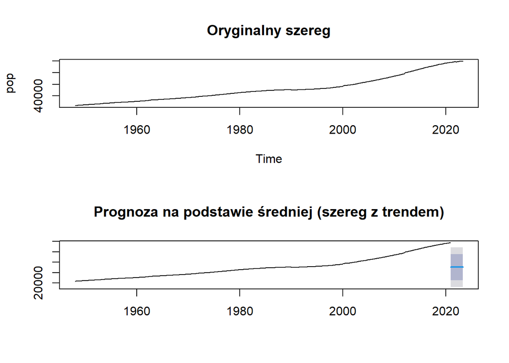

```r
popwyciete <- window(pop, start = c(1948,1), end = c(2020,12))

pop.meanf <- meanf(popwyciete, h = 29)
par(mfrow=c(2,1))
plot(pop, main="Oryginalny szereg")
plot(pop.meanf, main="Prognoza na podstawie średniej (szereg z trendem)")
```

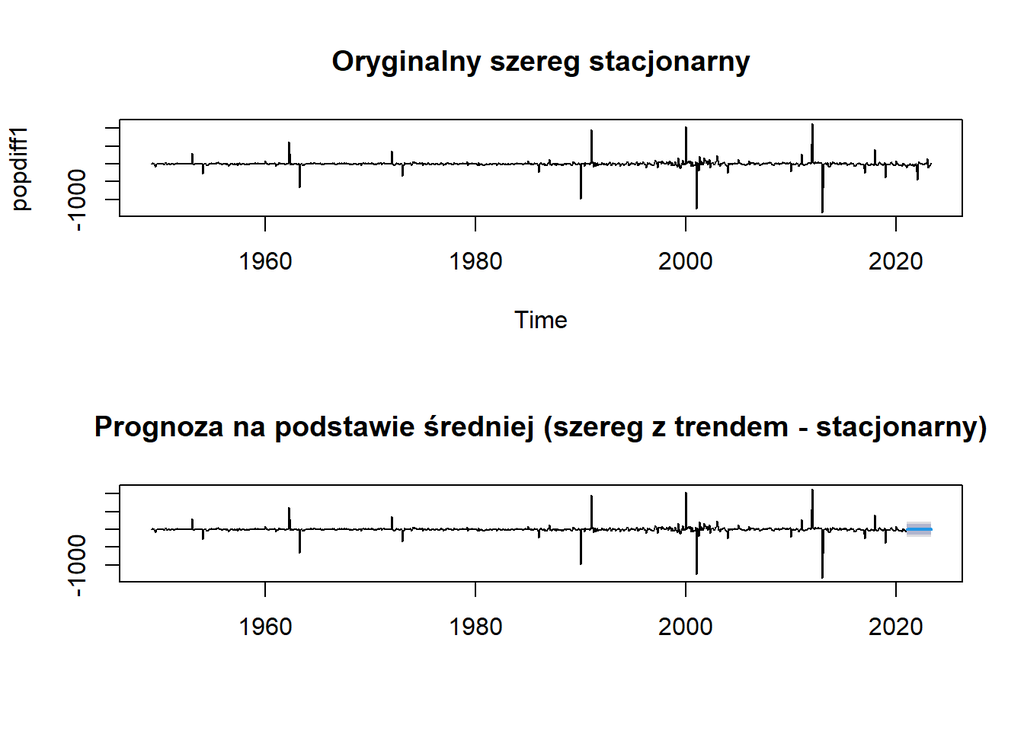

```r
popdiff1wyciete <- window(popdiff1, start = c(1949,2), end = c(2020,12))

pop.meanf1 <- meanf(popdiff1wyciete, h = 29)
par(mfrow=c(2,1))
plot(popdiff1, main="Oryginalny szereg stacjonarny")
plot(pop.meanf1, main="Prognoza na podstawie średniej (szereg z trendem - stacjonarny)")
```

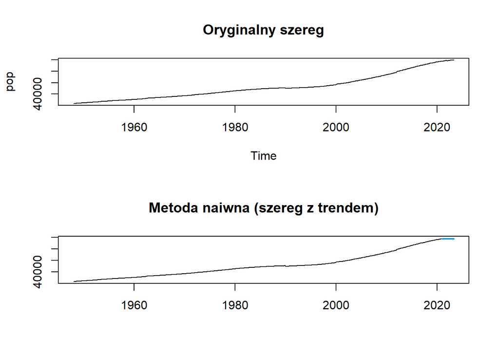

```r
pop.naive <- naive(popwyciete, h=29)
par(mfrow=c(2,1))
plot(pop, main="Oryginalny szereg")
plot(pop.naive, main="Metoda naiwna (szereg z trendem)")
```

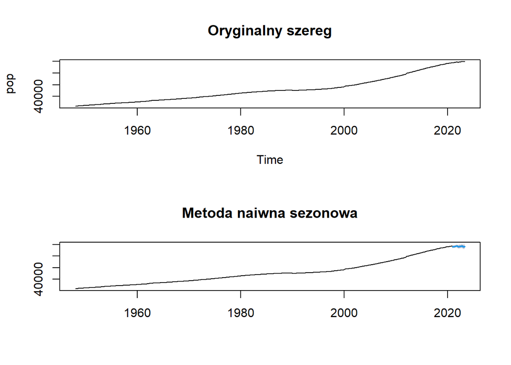

```r
pop.snaive <- snaive(popwyciete, h=29)
par(mfrow=c(2,1))
plot(pop, main="Oryginalny szereg")
plot(pop.snaive, main="Metoda naiwna sezonowa")
```

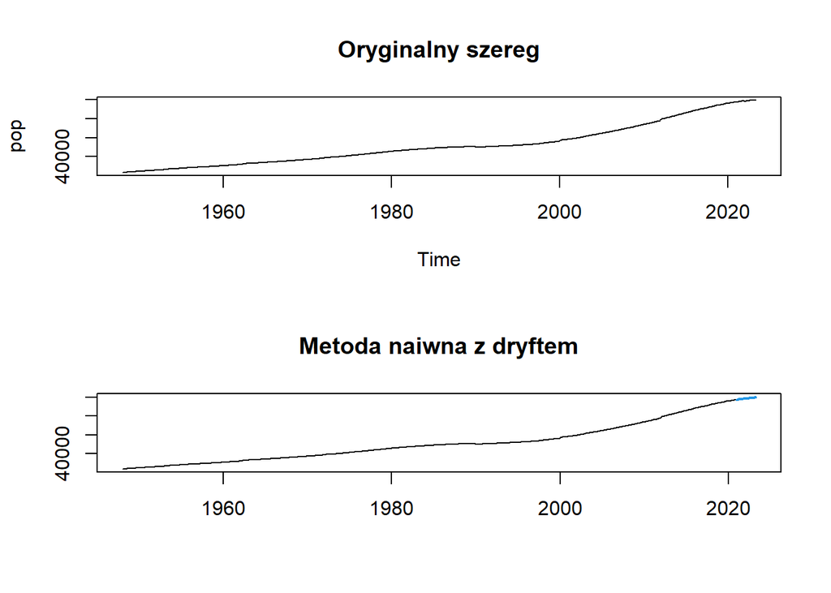

```r
pop.dryft <- rwf(popwyciete, h=28, drift = TRUE)
par(mfrow=c(2,1))
plot(pop, main="Oryginalny szereg")
plot(pop.dryft, main="Metoda naiwna z dryftem")
```

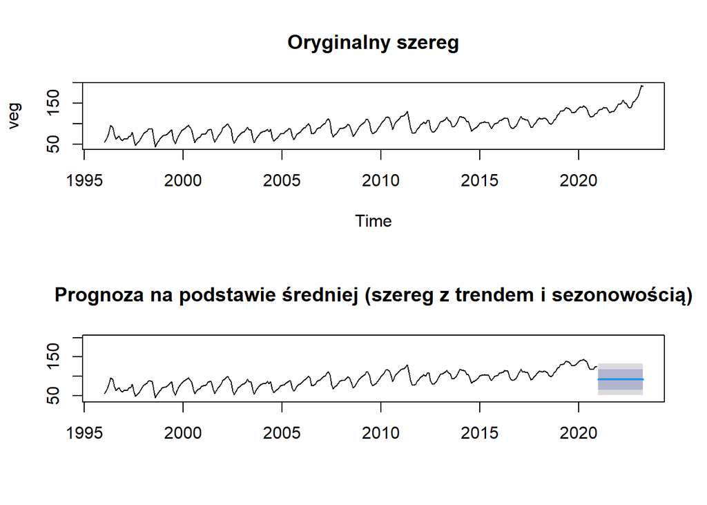

```r
vegwyciete <- window(veg, start = c(1996,1), end = c(2020,12))

veg.meanf <- meanf(vegwyciete, h = 28)
par(mfrow=c(2,1))
plot(veg, main="Oryginalny szereg")
plot(veg.meanf, main="Prognoza na podstawie średniej (szereg z trendem i sezonowością)", ylim=c(40,200))
```

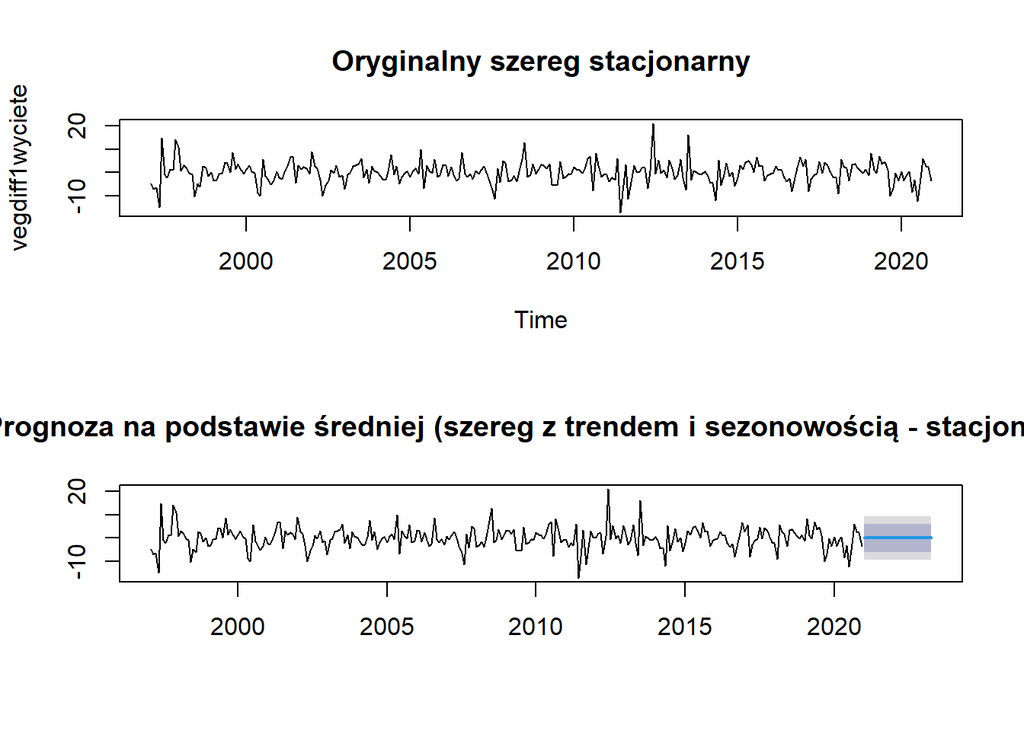

```r
vegdiff1wyciete <- window(vegdiff1, start = c(1997,2), end = c(2020,12))

veg.meanf1 <- meanf(vegdiff1wyciete, h = 28)
par(mfrow=c(2,1))
plot(vegdiff1wyciete, main="Oryginalny szereg stacjonarny")
plot(veg.meanf1, main="Prognoza na podstawie średniej (szereg z trendem i sezonowością - stacjonarny)")
```

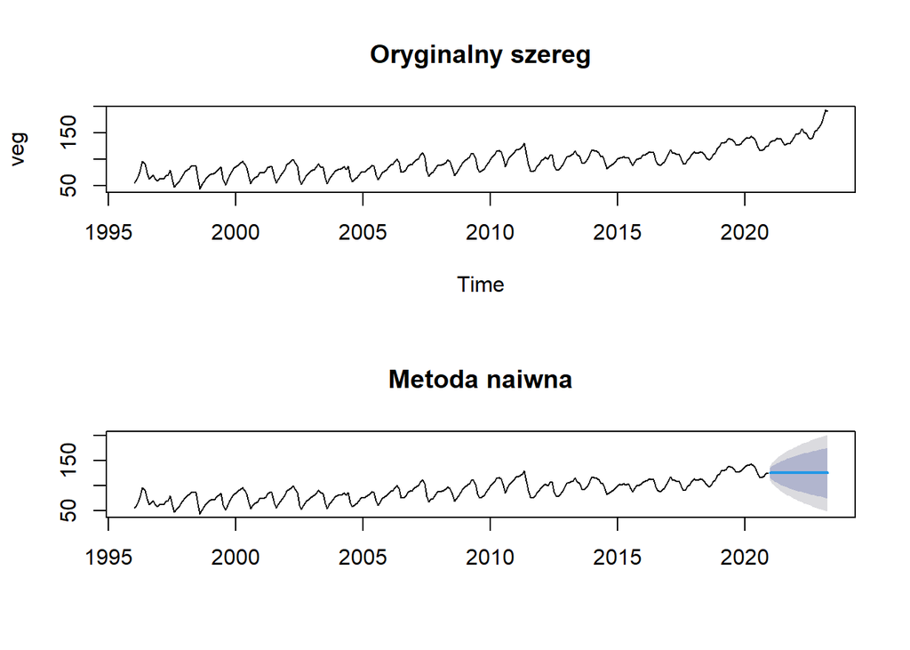

```r
veg.naive <- naive(vegwyciete, h=28)
par(mfrow=c(2,1))
plot(veg, main="Oryginalny szereg")
plot(veg.naive, main="Metoda naiwna")
```

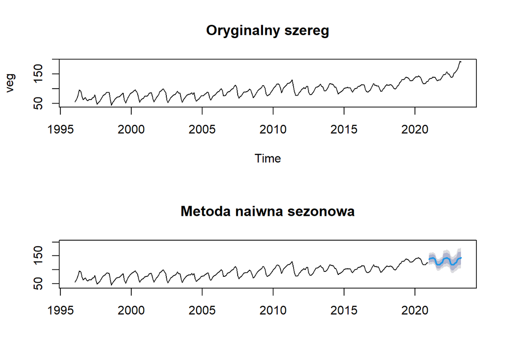

```r
veg.snaive <- snaive(vegwyciete, h=28)
par(mfrow=c(2,1))
plot(veg, main="Oryginalny szereg")
plot(veg.snaive, main="Metoda naiwna sezonowa",ylim=c(40,200))
```

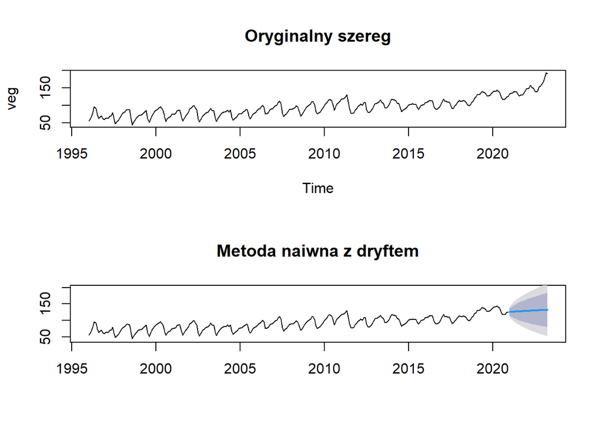

```r
veg.dryft <- rwf(vegwyciete, h=28, drift = TRUE)
par(mfrow=c(2,1))
plot(veg, main="Oryginalny szereg")
plot(veg.dryft, main="Metoda naiwna z dryftem",ylim=c(40,200))
```

# Prognozowanie z wykorzystaniem innych metod

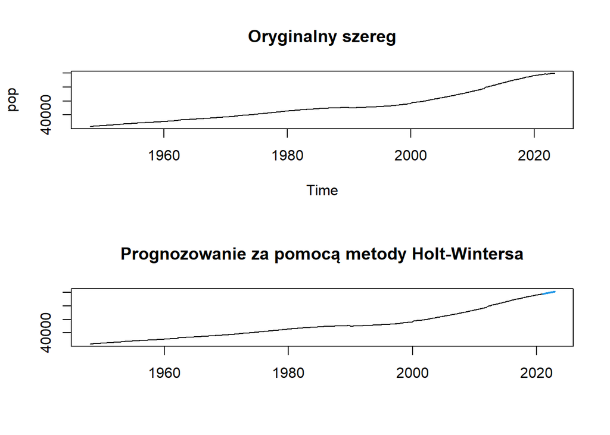

```r
hw.pop <- hw(popwyciete)
par(mfrow=c(2,1))
plot(pop, main="Oryginalny szereg")
plot(hw.pop, main="Prognozowanie za pomocą metody Holt-Wintersa")
```

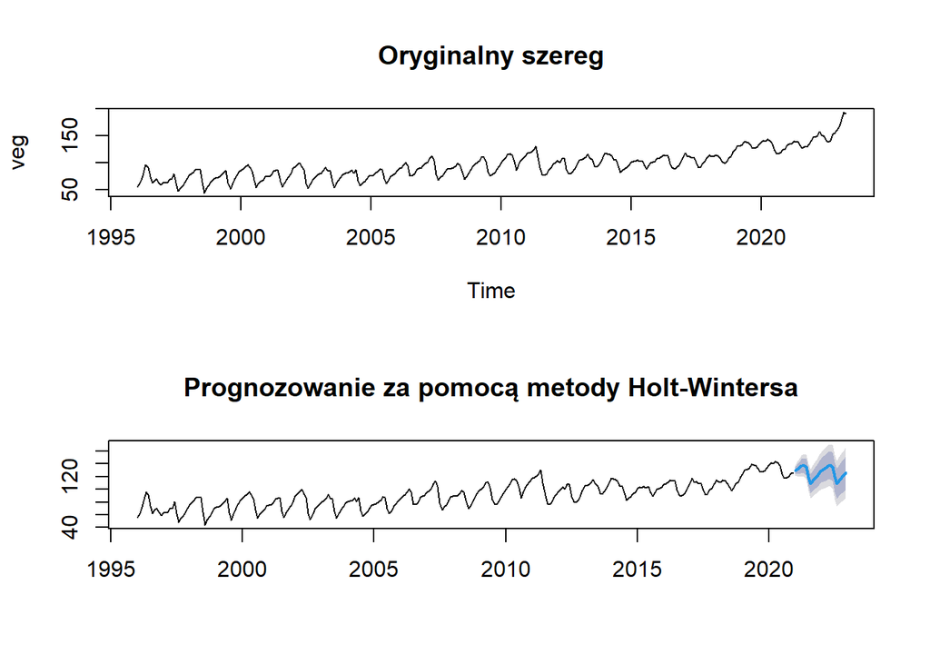

```r
hw.veg <- hw(vegwyciete)
par(mfrow=c(2,1))
plot(veg, main="Oryginalny szereg")
plot(hw.veg, main="Prognozowanie za pomocą metody Holt-Wintersa")
```

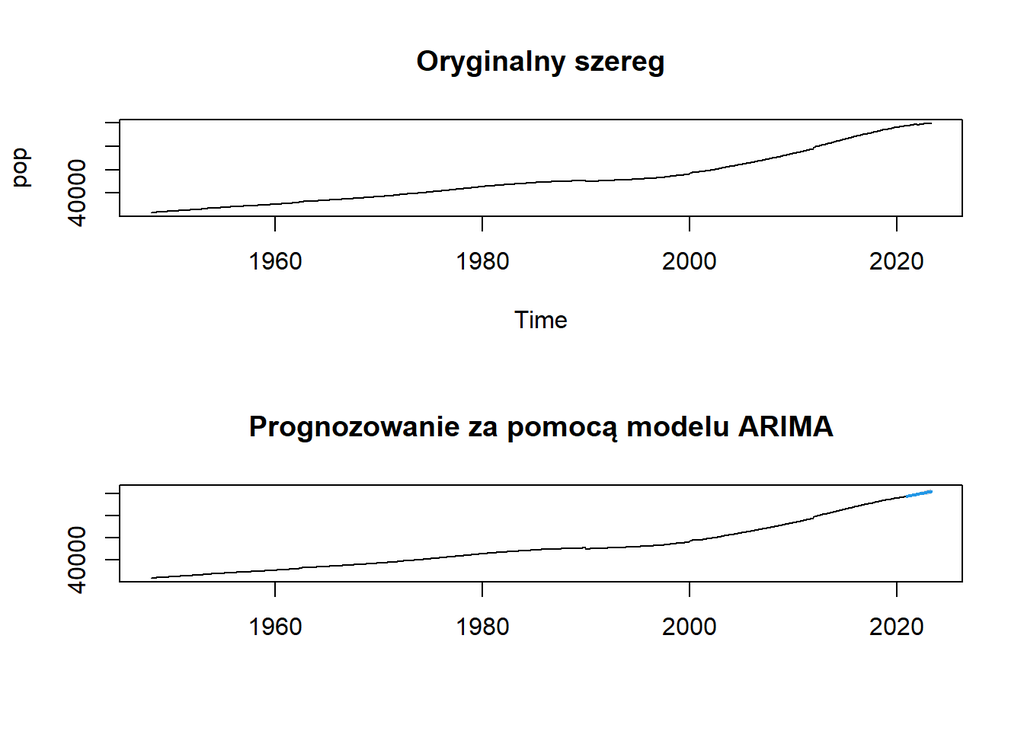

```r
arima.pop <- forecast(popwyciete, h=29)
par(mfrow=c(2,1))
plot(pop, main="Oryginalny szereg")
plot(arima.pop, main="Prognozowanie za pomocą modelu ARIMA")
```

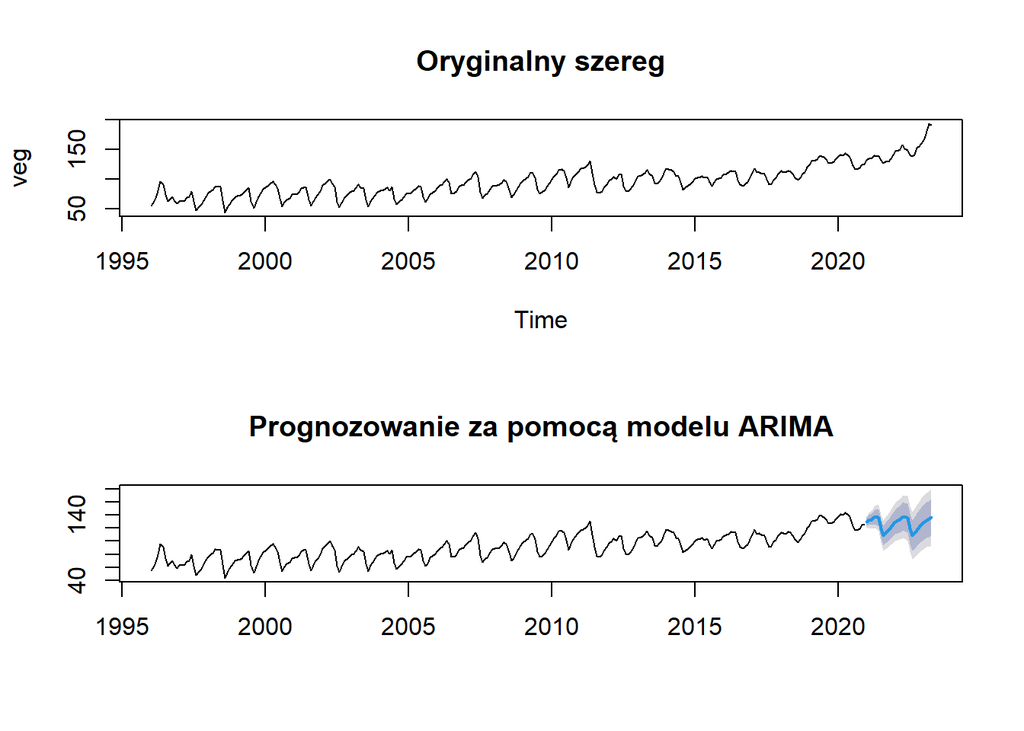

```r
arima.veg <- forecast(vegwyciete, h=28)
par(mfrow=c(2,1))
plot(veg, main="Oryginalny szereg")
plot(arima.veg, main="Prognozowanie za pomocą modelu ARIMA")
```

## Ocena jakości przeprowadzonych prognoz

Za pomocą funkcji accuracy() z pakietu forecast obliczyłam miary jakości prognoz.  
Im bardziej wartości zbliżone do 0, tym lepsza jest prognoza.  
W przypadku błędu średniokwadratowego (RMSE) i średniego błędu bezwzględnego (MAE), niższe wartości wskazują na lepsze dopasowanie prognoz. Można również uwzględnić błąd procentowy bezwzględny (MAPE), gdzie niższe wartości wskazują na mniejsze procentowe odchylenie prognoz.

```r
accuracy(pop.meanf)
```

```
##                        ME     RMSE      MAE       MPE     MAPE     MASE
## Training set 3.467059e-13 19462.45 15320.43 -15.27211 34.63657 14.82063
##                   ACF1
## Training set 0.9955175
```

```r
accuracy(pop.meanf1)
```

```
##                        ME     RMSE      MAE  MPE MAPE      MASE        ACF1
## Training set 2.924868e-16 110.4268 33.43246 -Inf  Inf 0.5677487 0.001068065
```

```r
accuracy(pop.naive)
```

```
##                    ME     RMSE    MAE      MPE      MAPE       MASE      ACF1
## Training set 84.87886 128.3249 88.584 0.163368 0.1702062 0.08569411 0.3072776
```

```r
accuracy(pop.snaive)
```

```
##                    ME     RMSE      MAE      MPE     MAPE MASE      ACF1
## Training set 1016.554 1231.746 1033.723 1.937321 1.971685    1 0.9869691
```

```r
accuracy(pop.dryft)
```

```
##                         ME     RMSE      MAE         MPE      MAPE       MASE
## Training set -1.613305e-12 96.24379 54.23525 -0.03062093 0.1088063 0.05246592
##                   ACF1
## Training set 0.3072776
```

```r
accuracy(hw.pop)
```

```
##                   ME     RMSE      MAE         MPE       MAPE       MASE
## Training set 2.24168 80.66612 26.56037 0.003828993 0.05276482 0.02569388
##                       ACF1
## Training set -0.0007912466
```

```r
accuracy(arima.pop)
```

```
##                    ME     RMSE      MAE         MPE       MAPE       MASE
## Training set 2.505792 81.54922 26.83923 0.004337518 0.05207203 0.02596365
##                      ACF1
## Training set 0.0006091052
```

```r
accuracy(veg.meanf)
```

```
##                        ME     RMSE      MAE       MPE     MAPE     MASE
## Training set 2.150317e-15 20.62089 16.79017 -5.504834 19.85297 1.956611
##                  ACF1
## Training set 0.926086
```

```r
accuracy(veg.meanf1)
```

```
##                         ME     RMSE      MAE MPE MAPE      MASE       ACF1
## Training set -4.442207e-17 4.757295 3.437929 Inf  Inf 0.5781036 0.09869153
```

```r
accuracy(veg.naive)
```

```
##                     ME     RMSE      MAE        MPE     MAPE      MASE
## Training set 0.2351171 7.402655 5.651171 -0.1856306 7.007487 0.6585486
##                   ACF1
## Training set 0.4198566
```

```r
accuracy(veg.snaive)
```

```
##                    ME     RMSE     MAE     MPE     MAPE MASE      ACF1
## Training set 2.508333 10.68505 8.58125 1.96687 9.219082    1 0.8929986
```

```r
accuracy(veg.dryft)
```

```
##                        ME    RMSE      MAE        MPE     MAPE      MASE
## Training set 3.897144e-15 7.39892 5.574027 -0.4564918 6.922158 0.6495589
##                   ACF1
## Training set 0.4198566
```

```r
accuracy(hw.veg)
```

```
##                     ME     RMSE      MAE        MPE     MAPE      MASE
## Training set 0.1637781 4.018103 2.843141 0.02539571 3.312927 0.3313201
##                    ACF1
## Training set 0.09031392
```

```r
accuracy(arima.veg)
```

```
##                    ME     RMSE      MAE        MPE     MAPE      MASE
## Training set 0.188679 3.997686 2.828672 0.06825739 3.291169 0.3296341
##                    ACF1
## Training set 0.09183656
```